# Supplement: analysis documentation

Physiologically-relevant light exposure and light behaviour in Switzerland and Malaysia

Authors

Affiliations

Anna Biller

Technical University of Munich, Germany

Max Planck Institute for Biological Cybernetics, Germany

Johannes Zauner

Technical University of Munich, Germany

Max Planck Institute for Biological Cybernetics, Germany

Christian Cajochen

Centre for Chronobiology, University Psychiatric Clinics Basel (UPK), Basel, Switzerland

Marisa A Gerle

Centre for Chronobiology, University Psychiatric Clinics Basel (UPK), Basel, Switzerland

Vineetha Kalavally

Monash University Malaysia, Electrical and Computer Systems Engineering, Intelligent Lighting Laboratory, Malaysia

Anas Mohamed

Monash University Malaysia, Electrical and Computer Systems Engineering, Intelligent Lighting Laboratory, Malaysia

Lukas Rottländer

Centre for Chronobiology, University Psychiatric Clinics Basel (UPK), Basel, Switzerland

Ming-Yi Seah

Monash University Malaysia, Electrical and Computer Systems Engineering, Intelligent Lighting Laboratory, Malaysia

Oliver Stefani

Lucerne School of Engineering and Architecture, Lucerne University of Applied Sciences and Arts, Horw, Switzerland

Manuel Spitschan

Technical University of Munich, Germany

Max Planck Institute for Biological Cybernetics, Germany

Technical University of Munich, Institute for Advanced Study (TUM-IAS), Germany

Last modified:

August 14, 2025

Doi

10.5281/zenodo.16872096

## 1 Preface

This is the analysis supplement to the publication “[*Physiologically-relevant light exposure and light behaviour in Switzerland and Malaysia*](https://doi.org/10.1101/2025.01.07.631760)”, as per the [OSF Preregistration from 18 October 2024, version v1.0.1](https://osf.io/pd79m).

**note: Creation of this analysis document based on its original script will fail, unless the recorded renv libraries are restored**

In short, light exposure was measured in Basel, Switzerland, and Kuala Lumpur, Malaysia, for one month in 20 individuals per site. Additionally, questionnaires on sleep (PSQI) and light exposure behaviour ([LEBA](https://leba-instrument.org)) were collected at specified times. The following hypotheses and research questions were formulated.

### 1.1 Research questions

- **RQ 1**: Are there differences in objectively measured light exposure between the two sites, and if so, in which light metrics?
- **RQ 2**: Are there differences in self-reported light exposure patterns using LEBA across time or between the two sites, and if so, in which questions/scores?
- **RQ 3** In general, how are light exposure and LEBA related and are there differences in this relationship between the two sites?

### 1.2 Hypotheses

For **RQ 1**, the following hypotheses will be addressed:

- **$H1$**: There are differences in light logger-derived light exposure intensity levels and duration of intensity between Malaysia and Switzerland.
- **$H0_1$** : No differences between Malaysia and Switzerland.
- **$H2$**: There are differences in light logger-derived timing of light exposure between Malaysia and Switzerland.
- **$H0_2$**: No differences between Malaysia and Switzerland.

For **RQ 2**, the following hypotheses will be addressed:

- **$H3$**: There are differences in LEBA items and factors between Malaysia and Switzerland.
- **$H0_3$**: No differences between Malaysia and Switzerland.
- **$H4$**: LEBA scores vary over time within participants.
- **$H0_4$**: No differences between Malaysia and Switzerland.

For **RQ 3**, the following hypotheses will be addressed:

- **$H5$**: LEBA items correlate with preselected light-logger derived light exposure variables.
- **$H0_5$**: No correlation.
- **$H6$**: There is a difference between Malaysia and Switzerland on how well light-logger derived light exposure variables correlate with subjective LEBA items.
- **$H0_6$**: No differences between Malaysia and Switzerland.

## 2 Summary

This analysis shows several key differences and similarities between the two sites, Malaysia and Switzerland.

## 3 Setup

Data analysis is performed in `R` statistical software, mainly using the [`LightLogR`](https://tscnlab.github.io/LightLogR/) R package, which is developed as part of the MeLiDos project. The document is rendered to HTML via [Quarto](https://quarto.org/).

The following packages are used for analysis

```r
#collect all the packages that are needed for the analysis
library(tidyverse)
library(cowplot)
library(gt)
library(gtsummary)
library(patchwork)
library(readxl)
library(ggsci)
library(ggcorrplot)
library(LightLogR)
library(rlang)
library(suntools)
library(legendry)
library(here)
library(lme4)
library(lmerTest)
library(broom.mixed)
library(lattice)
library(magrittr)
library(mgcv)
library(itsadug)
library(labelled)
library(ordinal)
library(ggtext)
library(magick)
library(ggh4x)
library(circular)
library(webshot2)
library(rnaturalearthdata)
library(gratia)

#source functions
source(here("functions/missing_data_table.R"))
source(here("functions/data_sufficient.R"))
source(here("functions/photoperiod.R"))
source(here("functions/table_lmer.R"))
source(here("functions/Inf_plots.R"))
source(here("functions/inference.R"))
source(here("functions/inference_table.R"))

#setting a seed for the date of generation to ensure reproducibility of random processes
seed <- 20241105

#if OpenMP is supported by the executing machine, analysis times for Research Question 2, Hypothesis 2, Patterns, can be sped up dramatically. If not supported, however, it distorts results dramatically and should not be used.
OpenMP_support <- TRUE
```

### 3.1 Global parameters

Here we set global parameters for the analysis. Except for the seed, these are specified in the preregistration document.

#### 3.1.1 Coordinates and timezones of the sites

Coordinates are specified as latitude and longitude in decimal degrees. Timezones are chosen from the `OlsonNames()` function.

```r
coordinates <- list(
#Basel Switzerland, University of Basel
malaysia = c(101.6009, 3.0650),
#Kuala Lumpur Malaysia, Monash University
switzerland = c(7.5839, 47.5585)
)

tzs <- list(
  malaysia = "Asia/Kuala_Lumpur",
  switzerland = "Europe/Zurich")
```

#### 3.1.2 Illuminance threshold

The upper measurement threshold is set to 130,000 lx. While a lower threshold of 1 lx is specified in the preregistration, it will not be applied in the analysis, as variances of light levels below 1 lx are not relevant for the analysis parameters.

```r
#set a maximum illuminance threshold in lx that is acceptable for the sensor values
illuminance_upper_th <- 1.3*10^5
```

#### 3.1.3 Random metrics for the sensitivity analysis

The preregistration document specifies the procedure to define a threshold of missing data through a sensitivity analysis, based on three random metrics. These are defined here. The metrics are taken from Table 5 in the preregistration document with the exception of Interdaily Stability (IS), which cannot be calculated on a daily basis as the others.

```r
#choosing three random metrics. This was the original script used to determine the metrics
# metrics <- c("TAT 250", "TAT 1000", "Period above 1000 lx", "M10m", "L5m", "IV", "LLiT 10", "LLit 250", "Frequency crossing threshold", "FLiT 1000", "LE", "M/P ratio")
#
# metrics_sample <-
#   sample(metrics, 3)
metrics_sample <- c("Llit 10","M/P ratio", "IV")
```

## 4 Import

### 4.1 Loading data in

**Malaysia data**

#### 4.1.1 Import light exposure data

The data sits in a folder structure that is organized by country and participant ID. Only `.csv` files that do not contain `qualtrics` in their file name from the subfolder `Malaysia/` are imported. The data is imported using the `Speccy` import function of the `LightLogR` package, as this is the device used. The function automatically detects the participant ID from the file name. The timezone set is for **Malaysia**.

*Note: Participant MY006 is missing from the data, as this participant lost the measurement device*

```r
#get all files in the Input/Malaysia folder that is inside a subfolder "MY001" to "MY020" and that does not contain "qualtrics" in the file name
base_folder <- "data/Malaysia"
ids <- sprintf("MY%03d", c(1:5, 7:20))
pattern <- "^(?!.*qualtrics).*\\.csv$"
all_folders <- file.path(base_folder, ids)
csv_files <-
  list.files(
    path = all_folders, pattern = "\\.csv$", full.names = TRUE, recursive = TRUE
    )
csv_files <- csv_files[!str_detect(csv_files, "qualtrics")]
id.pattern <- "MY[0-9]{3}"

#Import the data
data_malaysia <-
  import$Speccy(csv_files, tz = tzs[["malaysia"]], auto.id = id.pattern)
```

```
Successfully read in 733'908 observations across 19 Ids from 40 Speccy-file(s).
Timezone set is Asia/Kuala_Lumpur.
The system timezone is Europe/Berlin. Please correct if necessary!

First Observation: 2023-11-20 10:13:58
Last Observation: 2023-12-30 00:30:00
Timespan: 40 days

Observation intervals:
   Id    interval.time              n pct
 1 MY001 60s (~1 minutes)       43330 100%
 2 MY001 65s (~1.08 minutes)        1 0%
 3 MY002 59s                        1 0%
 4 MY002 60s (~1 minutes)       22189 100%
 5 MY002 61s (~1.02 minutes)        1 0%
 6 MY002 9978s (~2.77 hours)        1 0%
 7 MY002 17965s (~4.99 hours)       1 0%
 8 MY002 32323s (~8.98 hours)       1 0%
 9 MY002 1202366s (~1.99 weeks)     1 0%
10 MY003 60s (~1 minutes)       43195 100%
# ℹ 35 more rows
```

[figure not shown]

```r
#renaming the wavelength columns
data_malaysia <-
  data_malaysia %>%
  rename_with(\(x) {
    paste0("WL_", x) %>% str_replace("[.][.][.]", "")
  },
  `...380`:`...780`
  )
```

#### 4.1.2 Missing data

The summary shows that all data were collected approximately at the same time, and about half of them are without gaps. The next section will make implicit gaps explicit. This will be done by creating a regular time series from first until last day of measurement. Minutes without an observation will be filled with `NA`.

```r
#check for gaps (implicit missing data)
data_malaysia %>% gap_finder()
#confirm that the regular epoch is 1 minute
data_malaysia %>% dominant_epoch()
```

```
# A tibble: 19 × 3
   Id    dominant.epoch   group.indices
   <fct> <Duration>               <int>
 1 MY001 60s (~1 minutes)             1
 2 MY002 60s (~1 minutes)             2
 3 MY003 60s (~1 minutes)             3
 4 MY004 60s (~1 minutes)             4
 5 MY005 60s (~1 minutes)             5
 6 MY007 60s (~1 minutes)             6
 7 MY008 60s (~1 minutes)             7
 8 MY009 60s (~1 minutes)             8
 9 MY010 60s (~1 minutes)             9
10 MY011 60s (~1 minutes)            10
11 MY012 60s (~1 minutes)            11
12 MY013 60s (~1 minutes)            12
13 MY014 60s (~1 minutes)            13
14 MY015 60s (~1 minutes)            14
15 MY016 60s (~1 minutes)            15
16 MY017 60s (~1 minutes)            16
17 MY018 60s (~1 minutes)            17
18 MY019 60s (~1 minutes)            18
19 MY020 60s (~1 minutes)            19
```

```r
#bring data into a regular time series of 1 minute
data_malaysia_temp <-
  data_malaysia %>% mutate(Datetime = round_date(Datetime, "1 minute"))
#check that no Datetime is present twice after rounding
stopifnot("At least one datetime is present twice after rounding" =
            data_malaysia_temp$Datetime %>% length() %>% {. == nrow(data_malaysia)}
          )

#show a summary of implicitly missing data
implicitly_missing_summary(data_malaysia_temp,
                           "Implicitly missing data in the Malaysia dataset", 60)
```

Implicitly missing data in the Malaysia dataset

|  | min | max | median | mean | total |
| --- | --- | --- | --- | --- | --- |
| Number of gaps | 0 | 7 | 0 | 1 | 21 |
| Duration missed by available data points | 0 days | 14 days | 0 days | 1 day | 29 days |
| Duration covered by available data points | 11 days | 30 days | 30 days | 26 days | 509 days |
| Number of missing data points | 0 | 21,040 | 0 | 2,200 | 41,796 |
| Number of available data points | 16,604 | 43,996 | 43,212 | 38,627 | 733,908 |
| Percentage of missing data points | 0.0% | 48.7% | 0.0% | 5.4% | 5.4% |

min, max, median, mean, and total values for 19 participants

```r
#make implicit gaps explicit
data_malaysia <- data_malaysia_temp %>% gap_handler(full.days = TRUE)
#check for gaps
data_malaysia %>% gap_finder()
#remove the temporary dataframe
rm(data_malaysia_temp)

#show values above the photopic illuminance thresholds
data_malaysia %>%
  filter(Photopic.lux > illuminance_upper_th) %>%
  select(Id, Datetime, Photopic.lux, MEDI) %>%
  gt(caption =
       paste("Values above", illuminance_upper_th, "lx photopic illuminance"))
```

Values above 130000 lx photopic illuminance

| Datetime | Photopic.lux | MEDI |
| --- | --- | --- |
| MY014 |  |  |
| 2023-12-22 14:26:00 | 133096.7 | 132775.7 |

```r
#apply the filter for the upper illuminance threshold
data_malaysia <-
data_malaysia %>%
  filter(Photopic.lux <= illuminance_upper_th | is.na(Photopic.lux)) %>%
  gap_handler()

#set illuminance values to 0.1 if they are below 1 lux (as the sensor does not measure below 1 lux, but 0.1 lx can be logarithmically transformed)
data_malaysia <-
  data_malaysia %>%
  mutate(MEDI = ifelse(Photopic.lux < 1, 0.1, MEDI))

#show a summary of data missing in general
data_malaysia %>% filter(!is.na(MEDI)) %>%
  implicitly_missing_summary(
                           "Missing data in the Malaysia dataset overall",
                           60)
```

Missing data in the Malaysia dataset overall

|  | min | max | median | mean | total |
| --- | --- | --- | --- | --- | --- |
| Number of gaps | 0 | 7 | 0 | 1 | 22 |
| Duration missed by available data points | 0 days | 14 days | 0 days | 1 day | 29 days |
| Duration covered by available data points | 11 days | 30 days | 30 days | 26 days | 509 days |
| Number of missing data points | 0 | 21,040 | 0 | 2,200 | 41,797 |
| Number of available data points | 16,604 | 43,996 | 43,211 | 38,627 | 733,907 |
| Percentage of missing data points | 0.0% | 48.7% | 0.0% | 5.4% | 5.4% |

min, max, median, mean, and total values for 19 participants

#### 4.1.3 Import LEBA data

In this section the LEBA data is imported. The data is stored in a `MYXXX_qualtrics.csv` file within each participant’s folder. It contains questionnaire data. Days are coded 1 to X (X being the last day), so the dates need to be connected with the dates from the light data.

```r
#Import the data
leba_folders <- file.path(base_folder, ids)
pattern <- "qualtrics\\.csv$"
leba_files <-
  list.files(path = leba_folders, pattern = pattern, full.names = TRUE)

leba_malaysia <-
  read_csv(leba_files, id = "file.path") %>%
  mutate(Id = str_extract(file.path, id.pattern) %>% as.factor(),
         Day = parse_number(`...1`)
         ) %>%
  select(Id, Day, starts_with("leba"))

#extract the questions from the data
leba_questions <- leba_malaysia[1,-c(1,2)] %>% unlist()

#set the factor levels for leba
leba_levels <- c("Never", "Rarely", "Sometimes", "Often", "Always")

#drop the first row and set the factor levels
leba_malaysia <-
  leba_malaysia %>%
  drop_na(Day) %>%
  mutate(across(starts_with("leba"), ~ factor(.x, levels = leba_levels)))

#drop rows with NA
leba_malaysia <- leba_malaysia %>% drop_na()

#set variable labels
var_label(leba_malaysia) <- leba_questions %>% as.list()
```

**Switzerland data**

#### 4.1.4 Import light exposure data

The Swiss data are structured by participant folders, with one or more `.csv` files by participant.

```r
#get all files in the data/Basel/Speccy folder that is inside a subfolder "ID01" to "ID20" and in those a .csv file
base_folder <- "data/Basel/Speccy"
subfolders <- sprintf("ID%02d", 1:20)
pattern <- "\\.csv$"
all_folders <- file.path(base_folder, subfolders)
csv_files <- list.files(path = all_folders, pattern = pattern, full.names = TRUE, recursive = TRUE)
id.pattern <- "ID\\d{2}"

#Import the data
data_switzerland <- import$Speccy(csv_files, tz = tzs[["switzerland"]], auto.id = id.pattern)
```

```
Successfully read in 799'088 observations across 20 Ids from 49 Speccy-file(s).
Timezone set is Europe/Zurich.
The system timezone is Europe/Berlin. Please correct if necessary!

First Observation: 2023-07-17 17:30:00
Last Observation: 2023-10-18 14:10:36
Timespan: 93 days

Observation intervals:
   Id    interval.time              n pct
 1 ID01  60s (~1 minutes)       35968 100%
 2 ID01  36180s (~10.05 hours)      1 0%
 3 ID01  67260s (~18.68 hours)      1 0%
 4 ID01  302520s (~3.5 days)        1 0%
 5 ID02  60s (~1 minutes)       43530 100%
 6 ID02  1538s (~25.63 minutes)     1 0%
 7 ID03  60s (~1 minutes)       43873 100%
 8 ID03  1488s (~24.8 minutes)      1 0%
 9 ID03  43282s (~12.02 hours)      1 0%
10 ID04  60s (~1 minutes)       41554 100%
# ℹ 39 more rows
```

[figure not shown]

```r
#renaming the wavelength columns
data_switzerland <-
  data_switzerland %>%
  rename_with(\(x) {
    paste0("WL_", x) %>% str_replace("[.][.][.]", "")
  },
  `...380`:`...780`
  )
```

#### 4.1.5 Missing data

The overview suggests there is implicit missing data, which will be cleaned the following way:

```r
#check for gaps (implicit missing data)
data_switzerland %>% gap_finder()
#confirm that the regular epoch is 1 minute
data_switzerland %>% dominant_epoch()
```

```
# A tibble: 20 × 3
   Id    dominant.epoch   group.indices
   <fct> <Duration>               <int>
 1 ID01  60s (~1 minutes)             1
 2 ID02  60s (~1 minutes)             2
 3 ID03  60s (~1 minutes)             3
 4 ID04  60s (~1 minutes)             4
 5 ID05  60s (~1 minutes)             5
 6 ID06  60s (~1 minutes)             6
 7 ID07  60s (~1 minutes)             7
 8 ID08  60s (~1 minutes)             8
 9 ID09  60s (~1 minutes)             9
10 ID10  60s (~1 minutes)            10
11 ID11  60s (~1 minutes)            11
12 ID12  60s (~1 minutes)            12
13 ID13  60s (~1 minutes)            13
14 ID14  60s (~1 minutes)            14
15 ID15  60s (~1 minutes)            15
16 ID16  60s (~1 minutes)            16
17 ID17  60s (~1 minutes)            17
18 ID18  60s (~1 minutes)            18
19 ID19  60s (~1 minutes)            19
20 ID20  60s (~1 minutes)            20
```

```r
#bring data into a regular time series of 1 minute
data_switzerland_temp <-
  data_switzerland %>% mutate(Datetime = round_date(Datetime, "1 minute"))
#check that no Datetime is present twice after rounding
stopifnot("At least one datetime is present twice after rounding" =
            data_switzerland_temp$Datetime %>% length() %>% {. == nrow(data_switzerland)}
          )

#show a summary of implicitly missing data
implicitly_missing_summary(data_switzerland_temp,
                           "Implicitly missing data in the Swiss dataset", 60)
```

Implicitly missing data in the Swiss dataset

|  | min | max | median | mean | total |
| --- | --- | --- | --- | --- | --- |
| Number of gaps | 1 | 4 | 1 | 1 | 29 |
| Duration missed by available data points | <1 day | 11 days | <1 day | 1 day | 28 days |
| Duration covered by available data points | 7 days | 30 days | 29 days | 27 days | 554 days |
| Number of missing data points | 20 | 16,017 | 40 | 2,034 | 40,680 |
| Number of available data points | 11,476 | 44,588 | 42,974 | 39,954 | 799,088 |
| Percentage of missing data points | 0.0% | 40.4% | 0.1% | 5.9% | 4.8% |

min, max, median, mean, and total values for 20 participants

```r
#make implicit gaps explicit
data_switzerland <- data_switzerland_temp %>% gap_handler(full.days = TRUE)
#check for gaps
data_switzerland %>% gap_finder()
#remove the temporary dataframe
rm(data_switzerland_temp)

#show values above the photopic illuminance thresholds
data_switzerland %>%
  filter(Photopic.lux > illuminance_upper_th) %>%
  select(Id, Datetime, Photopic.lux, MEDI) %>%
  gt(caption =
       paste("Values above", illuminance_upper_th, "lx photopic illuminance"))
```

Values above 130000 lx photopic illuminance

| Datetime | Photopic.lux | MEDI |
| --- | --- | --- |
| ID01 |  |  |
| 2023-08-07 15:10:00 | 1.302806e+05 | 1.345450e+05 |
| ID03 |  |  |
| 2023-08-09 16:49:00 | 1.350211e+05 | 1.347234e+05 |
| ID07 |  |  |
| 2023-09-05 13:56:00 | 1.455028e+05 | 1.298996e+05 |
| 2023-09-06 13:35:00 | 1.370206e+05 | 1.223984e+05 |
| ID18 |  |  |
| 2023-09-26 19:28:00 | 1.267747e+27 | 9.370563e+23 |
| 2023-09-26 19:32:00 | 1.267747e+27 | 9.370563e+23 |
| 2023-09-26 19:34:00 | 1.575518e+15 | 1.613236e+12 |
| 2023-09-26 19:36:00 | 1.267747e+27 | 9.370563e+23 |

```r
#apply the filter for the upper illuminance threshold
data_switzerland <-
data_switzerland %>%
  filter(Photopic.lux <= illuminance_upper_th | is.na(Photopic.lux)) %>%
  gap_handler()

#set illuminance values to 0.1 if they are below 1 lux (as the sensor does not measure below 1 lux, but 0.1 lx can be logarithmically transformed)
data_switzerland <-
  data_switzerland %>%
  mutate(MEDI = ifelse(Photopic.lux < 1, 0.1, MEDI))

#show a summary of data missing in general
data_switzerland %>% filter(!is.na(MEDI)) %>%
  implicitly_missing_summary(
                           "Missing data in the Swiss dataset overall",
                           60)
```

Missing data in the Swiss dataset overall

|  | min | max | median | mean | total |
| --- | --- | --- | --- | --- | --- |
| Number of gaps | 1 | 4 | 1 | 2 | 35 |
| Duration missed by available data points | <1 day | 11 days | <1 day | 1 day | 28 days |
| Duration covered by available data points | 7 days | 30 days | 29 days | 27 days | 554 days |
| Number of missing data points | 21 | 16,017 | 44 | 2,035 | 40,698 |
| Number of available data points | 11,476 | 44,586 | 42,974 | 39,954 | 799,070 |
| Percentage of missing data points | 0.0% | 40.4% | 0.1% | 5.9% | 4.8% |

min, max, median, mean, and total values for 20 participants

#### 4.1.6 Import LEBA data

In this section the LEBA data is imported. The data is stored in the `REDCap_CajochenASEAN_DATA_2023-10-30_1215.csv` file in the `REDCap` folder. It contains questionnaire data. Days are coded 1 to X (X being the last day), so the dates need to be connected with the dates from the light data.

The basel data also contains more columns coded with `leba` than the Malaysia data. Only the ones contained in both locations will be chosen.

```r
#Import the data
leba_folders <- "data/Basel/REDCap"
leba_file <- "REDCap_CajochenASEAN_DATA_2023-10-30_1215.csv"
leba_files <- paste(leba_folders, leba_file, sep = "/")

leba_switzerland <-
  read_csv(leba_files, id = "file.path") %>%
  mutate(Day = parse_number(redcap_event_name)) %>%
  fill(code) %>%
  select(Id = code, Day, starts_with("leba"))

#replace the small factor f to an uppercase F
names(leba_switzerland) <-
names(leba_switzerland) %>% str_replace_all("f(\\d)", "F\\1")

#set the factor levels for leba
leba_levels <- c("Never", "Rarely", "Sometimes", "Often", "Always")

#get the column names
colnames_leba <- names(leba_questions)

#merge the columns with the same name, where one ends with _2, unite the dates
leba_switzerland <-
  colnames_leba %>%
  reduce(
    \(y,x)
    y %>%
      unite(
        col = !!x,
        matches(x), matches(paste0(x, "_2")),
        na.rm = TRUE
        ),
    .init = leba_switzerland
    ) %>%
  unite(col = Datetime,
        leba_weekly_timestamp, leba_end_timestamp,
        na.rm = TRUE) %>%
  select(Id, Day, Datetime, starts_with("leba_f")) %>%
  mutate(across(starts_with("leba"),
           ~ factor(.x, levels = 1:5, labels = leba_levels))) %>%
  drop_na()

#set variable labels
var_label(leba_switzerland) <- leba_questions %>% as.list()
```

As the codes in REDCap and the Ids in the light data do not match, we need to enlist a conversion table.

```r
file_conv <- "data/Basel/Participant List Anonymised.xlsx"
#import the conversion file
conv_switzerland <-
  read_xlsx(file_conv) %>%
  select(ID, Code) %>%
  mutate(ID = sprintf("ID%02d", ID))

#one Id in the conversion file does not match with a code in the Leba data
# conversion file: 1998NABR
# leba data: 1999NABR
# we correct the conversion file according to the leba data
conv_switzerland <-
  conv_switzerland %>%
  mutate(Code = if_else(Code == "1998NABR", "1999NABR", Code))

#add the conversion table to the leba data
leba_switzerland <-
  leba_switzerland %>%
  left_join(conv_switzerland, by = c("Id" = "Code")) %>%
  select(-Id) %>%
  rename(Id = ID) %>%
  drop_na(starts_with("leba")) %>%
  dplyr::relocate(Id, .before = 1)
```

#### 4.1.7 Determining the cutoff for required data of participant-days

Each participant-day is required to have at least a set number of datapoints or it will be excluded from the analysis. The procedure on how to determine this cutoff is described in the preregistration document. Data will be aggregated to hourly values and threshold values in 1 hour instances tested, i.e. 1/24 of a day. The minimum threshold is set to 3/24, as calculating the IV requires 3 data points. Participants `MY004`, `MY009`, and `MY012` were chosen randomly to determine the threshold.

This section took about 40 hrs compute time on a M2 Macbook Pro, 64 GB RAM. Thus for normal execution, bootstrapped results are stored in `data/processed`, and only analysed here.

```r
#choosing three participants without missing data.

# n_participants <- 3
#
# coverage <-
# data_malaysia %>% filter(!is.na(MEDI)) %>%
#     summarize(
#       length_no_complete = length(Datetime),
#       length_days = length_no_complete/60/24
#     )
#
# random_participants <-
# suppressWarnings({
#   data_malaysia %>%
#     filter(!is.na(MEDI)) %>%
#     gap_finder(gap.data = TRUE, silent = TRUE) %>%
#         group_by(Id, .drop = FALSE) %>%
#         summarise(gaps = max(gap.id)
#         ) %>%
#         mutate(gaps = ifelse(gaps == -Inf, 0, gaps))
#     }) %>%
#   left_join(coverage, by = "Id") %>%
#   filter(gaps == 0 & length_days >=29) %>%
#   slice_sample(n = n_participants) %>%
#   pull(Id)

random_participants <- c("MY004", "MY009", "MY012")
```

The chosen metrics are Llit 10, M/P ratio, IV, the chosen participants are MY004, MY009, MY012.

##### 4.1.7.1 Calculating metrics

```r
#filter the dataset
subset_malaysia <-
  data_malaysia %>%
  filter(Id %in% random_participants)

#remove the (incomplete) first and last day of measurement
subset_malaysia <-
  subset_malaysia %>%
  aggregate_Datetime(unit = "1 hour") %>%
  mutate(Day = date(Datetime)) %>%
  filter_Datetime(filter.expr =
                    Day > min(Day) & Day < (max(Day)-days(1)))

subset_malaysia %>% gg_overview()
```

[figure not shown]

```r
#metrics function
metrics_function <- function(dataset) {
  dataset %>%
    summarize(
    MP_ratio = mean(MEDI)/mean(Photopic.lux),
            LLiT10 =
              timing_above_threshold(
              MEDI, Datetime, "below", 10, as.df = TRUE),
            IV = intradaily_variability(MEDI, Datetime),
            .groups = "drop_last"
            ) %>%
  unnest_wider(col = c(LLiT10)) %>%
  select(-first_timing_below_10, -mean_timing_below_10) %>%
    mutate(last_timing_below_10 =
             hms::as_hms(last_timing_below_10) %>% as.numeric)
  }

# calculate the metrics
subset_metrics <-
  subset_malaysia %>%
  group_by(Day, .add = TRUE) %>%
  metrics_function() %>%
      pivot_longer(
        cols = -c(Day, Id), names_to = "metric", values_to = "value") %>%
  group_by(metric, Id) %>%
  summarize(
    mean = mean(value, na.rm = TRUE),
    sd = stats::sd(value, na.rm = TRUE),
    se = sd/sqrt(n()-1),
    qlower = quantile(value, 0.4, na.rm = TRUE),
    qupper = quantile(value, 0.6, na.rm = TRUE),
    upper_Acc = max(value, na.rm = TRUE),
    lower_Acc = min(value, na.rm = TRUE),
    .groups = "drop"
  )
```

##### 4.1.7.2 creating bootstraps

```r
#for each participant-day, remove the specified number of datapoints
#and calculate the metrics
bootstrap_basis <-
  subset_malaysia %>%
  group_by(Id, Day) %>%
  select(Id, Day, Datetime, MEDI, Photopic.lux)
```

```r
#thresholds for the bootstrapping
n_bootstraps <- 2
thresholds <- seq(1, 21, by = 1)

#create the bootstraps

#this is commented out in production, because the process takes about 40+ hours of compute-time

#creating 5000 files with 2 bootstraps each
# (1:(0.5*10^4)) %>% walk(\(x) {
#
#   bootstraps <-
#   tibble(
#     threshold = rep(thresholds, each = n_bootstraps),
#     bootstrap_id = seq_along(threshold),
#          data =
#            threshold %>% map(\(x) bootstrap_basis %>% slice_sample(n = 24-x))
#   ) %>%
#   unnest(data) %>%
#   group_by(threshold, bootstrap_id, Id, Day) %>%
#   arrange(Datetime, .by_group = TRUE) %>%
#   metrics_function() %>%
#   pivot_longer(cols = -c(threshold, bootstrap_id, Id, Day), names_to = "metric", values_to = "value")
# #
# #save these to disk
# save(bootstraps, file = sprintf("data/processed/bootstrap%04d.RData", x))
#
# })
```

```r
#then bring the bootstraps together to one file

# bootdata <- tibble()

# walk(1:5000, \(x) {
#   load(sprintf("data/processed/bootstrap%04d.RData", x))
#   bootdata <<- bind_rows(bootdata, bootstraps)
# })

# bootstraps <- bootdata
# save(bootstraps, file = "data/processed/bootstraps.RData")
```

```r
#bootstrap condensation
# source("scripts/bootstrap_condensation.R")
```

```r
#if previous chunks for bootstrapping are executed, comment this chunk out
load(file = "data/processed/bootstraps.RData")
```

```r
#the bootstraps are now summarized at the metric per participant level for each threshold. These are compared to the original metrics and their bounds. bootstrap condensation in the script "scripts/bootstrap_condensation.R"
bootstrap_comparison <-
bootstraps %>%
  left_join(subset_metrics, by = c("Id", "metric"))

#visualize the results
bootstrap_comparison %>%
  ggplot(aes(x = threshold)) +
    geom_ribbon(aes(ymin = (mean - 2*se), ymax = (mean + 2*se)),
                fill = "steelblue", alpha = 0.4) +
  geom_hline(data = subset_metrics, aes(yintercept=mean), color = "steelblue") +
  geom_errorbar(
    aes(ymin = lower_bs1, ymax = upper_bs1), linewidth = 0.5, width = 0) +
  geom_errorbar(aes(ymin = lower_bs2, ymax = upper_bs2),
                linewidth = 0.25, width = 0) +
  geom_point(aes(y=mean_bs,
                 col = ((mean - 2*se) <= lower_bs3 & upper_bs3 <= (mean + 2*se)))) +
  facet_wrap(Id~metric, scales = "free") +
  theme_minimal() +
  labs(x = "Hours missing from the day (Threshold)", y = "Metric value", col = "Within Range") +
  theme(legend.position = "bottom")
```

[figure not shown]

Summmary of the bootstraping procedure to determine an acceptable threshold of daily missing data. The blue horizontal line shows the average value of data across the full dataset, the blue rectangle a 95% confidence interval around that average. Dots show the average value across all bootstraps of that respective threshold value. A blue dot indicates that all 10^4 bootstraps lie within the 95% confidence interval of the full dataset. A red dot indicates that at least one bootstrap lies outside of the 95% confidence interval.

The most conservative threshold is chosen based on participant `MY009` and the metric `last_timing_below_10`, which allows up to 6 hours of missing data per day, i.e. 25.00%. For this assumption to hold, the data must be missing at random hours of the day.

```r
missing_threshold <- 18/24
```

#### 4.1.8 Remove participant-days with insufficient data

The threshold determined in Section 4.1.7 is used to remove participant-days with insufficient data.

**Malaysia**

```r
#mark data that is above the upper illuminance threshold
data_malaysia <-
  data_malaysia %>%
  group_by(Day = date(Datetime), .add = TRUE) %>%
    mutate(marked_for_removal =
             !data_sufficient(MEDI, missing_threshold),
           .before = 1
          ) %>%
  ungroup(Day)

#display the final malaysia dataset prior to analysis, where each dot marks the start/end of a day
data_malaysia %>%
  filter(!marked_for_removal) %>%
  group_by(Day, .add = TRUE) %>%
  gg_overview()
```

[figure not shown]

**Switzerland**

```r
#mark data that is above the upper illuminance threshold
data_switzerland <-
  data_switzerland %>%
  group_by(Day = date(Datetime), .add = TRUE) %>%
    mutate(marked_for_removal =
             !data_sufficient(MEDI, missing_threshold),
           .before = 1
          ) %>%
  ungroup(Day)

#display the final malaysia dataset prior to analysis, where each dot marks the start/end of a day
data_switzerland %>%
  filter(!marked_for_removal) %>%
  group_by(Day, .add = TRUE) %>%
  gg_overview()
```

[figure not shown]

```r
#visualize the data as a doubleplot of an average day
data_malaysia %>%
  filter(!marked_for_removal) %>%
  ungroup() %>%
  aggregate_Date(numeric.handler = \(x) mean(x, na.rm = TRUE)) %>%
  gg_doubleplot(fill = pal_jco()(1))
```

[figure not shown]

```r
#visualize the data as a doubleplot of an average day
data_switzerland %>%
  filter(!marked_for_removal) %>%
  ungroup() %>%
  aggregate_Date(numeric.handler = \(x) mean(x, na.rm = TRUE)) %>%
  gg_doubleplot()
```

[figure not shown]

```r
# ggsave("figures/average_day_basel.pdf", height = 27)
```

### Combine datasets and descriptives

The datasets are combined into one dataset for further analysis.

**Light exposure data**

```r
#combine the light exposure data
data <- list(malaysia = data_malaysia %>% filter(!marked_for_removal),
             switzerland = data_switzerland %>% filter(!marked_for_removal))

descriptive <-
data %>% map(\(x) {
  x %>% tbl_summary(include = c(MEDI),
                              by = Id,
                              missing_text = "Missing",
                              statistic = list(
                                               MEDI ~ "{mean} ({min}, {max})")
                              )
})

descriptive[[1]]
```

| **Characteristic** | **MY001** N = 41,760<sup>1</sup> | **MY002** N = 20,160<sup>1</sup> | **MY003** N = 41,760<sup>1</sup> | **MY004** N = 41,760<sup>1</sup> | **MY005** N = 41,760<sup>1</sup> | **MY007** N = 41,760<sup>1</sup> | **MY008** N = 41,760<sup>1</sup> | **MY009** N = 41,760<sup>1</sup> | **MY010** N = 34,560<sup>1</sup> | **MY011** N = 40,320<sup>1</sup> | **MY012** N = 43,200<sup>1</sup> | **MY013** N = 41,760<sup>1</sup> | **MY014** N = 41,760<sup>1</sup> | **MY015** N = 41,760<sup>1</sup> | **MY016** N = 31,680<sup>1</sup> | **MY017** N = 43,200<sup>1</sup> | **MY018** N = 15,840<sup>1</sup> | **MY019** N = 43,200<sup>1</sup> | **MY020** N = 15,840<sup>1</sup> |
| --- | --- | --- | --- | --- | --- | --- | --- | --- | --- | --- | --- | --- | --- | --- | --- | --- | --- | --- | --- |
| MEDI | 266 (0, 102,316) | 124 (0, 49,984) | 183 (0, 102,319) | 246 (0, 77,476) | 207 (0, 104,484) | 224 (0, 67,146) | 148 (0, 101,702) | 512 (0, 109,127) | 176 (0, 79,192) | 68 (0, 50,185) | 127 (0, 58,776) | 289 (0, 116,735) | 440 (0, 125,709) | 134 (0, 34,199) | 188 (0, 67,580) | 159 (0, 89,517) | 175 (0, 62,551) | 138 (0, 109,826) | 97 (0, 81,403) |
| Missing | 0 | 187 | 0 | 0 | 0 | 0 | 0 | 0 | 114 | 196 | 0 | 25 | 1 | 0 | 57 | 13 | 514 | 370 | 0 |

<sup>1</sup> Mean (Min, Max)

```r
descriptive[[2]]
```

| **Characteristic** | **ID01** N = 33,120<sup>1</sup> | **ID02** N = 41,760<sup>1</sup> | **ID03** N = 41,760<sup>1</sup> | **ID04** N = 40,320<sup>1</sup> | **ID05** N = 40,320<sup>1</sup> | **ID06** N = 41,760<sup>1</sup> | **ID07** N = 43,200<sup>1</sup> | **ID08** N = 41,760<sup>1</sup> | **ID09** N = 8,640<sup>1</sup> | **ID10** N = 40,320<sup>1</sup> | **ID11** N = 41,760<sup>1</sup> | **ID12** N = 40,320<sup>1</sup> | **ID13** N = 41,760<sup>1</sup> | **ID14** N = 41,760<sup>1</sup> | **ID15** N = 23,040<sup>1</sup> | **ID16** N = 41,760<sup>1</sup> | **ID17** N = 41,760<sup>1</sup> | **ID18** N = 41,760<sup>1</sup> | **ID19** N = 40,320<sup>1</sup> | **ID20** N = 40,320<sup>1</sup> |
| --- | --- | --- | --- | --- | --- | --- | --- | --- | --- | --- | --- | --- | --- | --- | --- | --- | --- | --- | --- | --- |
| MEDI | 1,294 (0, 130,038) | 1,005 (0, 113,549) | 1,357 (0, 125,807) | 1,337 (0, 114,184) | 425 (0, 93,199) | 804 (0, 130,088) | 1,211 (0, 114,327) | 1,047 (0, 119,789) | 79 (0, 72,266) | 306 (0, 97,892) | 1,043 (0, 120,756) | 835 (0, 105,709) | 1,134 (0, 108,602) | 548 (0, 123,006) | 187 (0, 112,956) | 481 (0, 107,579) | 311 (0, 119,461) | 1,007 (0, 117,245) | 403 (0, 117,124) | 77 (0, 93,858) |
| Missing | 375 | 25 | 228 | 21 | 23 | 129 | 22 | 25 | 0 | 21 | 51 | 0 | 25 | 26 | 322 | 26 | 29 | 36 | 485 | 34 |

<sup>1</sup> Mean (Min, Max)

**LEBA data**

```r
#combine the leba data
leba_data <- list(malaysia = leba_malaysia, switzerland = leba_switzerland)
leba_data_combined <- leba_data %>% list_rbind(names_to = "site")
var_label(leba_data_combined) <- leba_questions %>% as.list()

#histogram summary
leba_data_combined %>%
  pivot_longer(cols = -c(site, Id, Day, Datetime),
               names_to = "item", values_to = "value") %>%
  group_by(site, item) %>%
  nest() %>%
  ungroup() %>%
  mutate(question = rep(leba_questions, 2)) %>%
  unnest_wider(data) %>%
  select(-c(Id,Day, Datetime)) %>%
  mutate(value = map(value, \(x) x %>% as.numeric() %>% hist(breaks = (0.5+0:5), plot = FALSE) %>% .$counts)) %>%
  pivot_wider(id_cols = c(question, item), names_from = site, values_from = value) %>%
  gt() %>%
  cols_nanoplot(new_col_name = "Malaysia",
                columns = c(malaysia), plot_type = "bar",
                options = nanoplot_options(
                  data_bar_fill_color = pal_jco()(1),
                  data_bar_stroke_color = pal_jco()(1)
                )) %>%
  cols_nanoplot(new_col_name = "Switzerland",
                columns = c(switzerland), plot_type = "bar",
                options = nanoplot_options(
                  data_bar_fill_color = pal_jco()(2)[2],
                  data_bar_stroke_color = pal_jco()(2)[2]
                )) %>%
  cols_label(question = "LEBA Item",
             item = "Item coding")
```

LEBA Item

Item coding

Malaysia

Switzerland

I wear blue-filtering, orange-tinted, and/or red-tinted glasses indoors during the day

leba_F1_01

[figure not shown]

I wear blue-filtering, orange-tinted, and/or red-tinted glasses outdoors during the day

leba_F1_02

[figure not shown]

I wear blue-filtering, orange-tinted, and/or red-tinted glasses within 1 hour before attempting to fall asleep

leba_F1_03

[figure not shown]

I spend 30 minutes or less per day (in total) outside

leba_F2_04

[figure not shown]

I spend between 30 minutes and 1 hour per day (in total) outside

leba_F2_05

[figure not shown]

I spend between 1 and 3 hours per day (in total) outside

leba_F2_06

[figure not shown]

I spend more than 3 hours per day (in total) outside

leba_F2_07

[figure not shown]

I spend as much time outside as possible

leba_F2_08

[figure not shown]

I go for a walk or exercise outside within 2 hours after waking up

leba_F2_09

[figure not shown]

I use my mobile phone within 1 hour before attempting to fall asleep

leba_F3_10

[figure not shown]

I look at my mobile phone screen immediately after waking up

leba_F3_11

[figure not shown]

I check my phone when I wake up at night

leba_F3_12

[figure not shown]

I look at my smartwatch within 1 hour before attempting to fall asleep

leba_F3_13

[figure not shown]

I look at my smartwatch when I wake up at night

leba_F3_14

[figure not shown]

I dim my mobile phone screen within 1 hour before attempting to fall asleep

leba_F4_15

[figure not shown]

I use a blue-filter app on my computer screen within 1 hour before attempting to fall asleep

leba_F4_16

[figure not shown]

I use as little light as possible when I get up during the night

leba_F4_17

[figure not shown]

I dim my computer screen within 1 hour before attempting to fall asleep

leba_F4_18

[figure not shown]

I use tunable lights to create a healthy light environment

leba_F5_19

[figure not shown]

I use LEDs to create a healthy light environment

leba_F5_20

[figure not shown]

I use a desk lamp when I do focused work

leba_F5_21

[figure not shown]

I use an alarm with a dawn simulation light

leba_F5_22

[figure not shown]

I turn on the lights immediately after waking up

leba_F5_23

[figure not shown]

```r
#numeric summary plot
leba_data_combined %>%
  tbl_summary(include = -c(Id, Day, Datetime), by = site)
```

| **Characteristic** | **malaysia** N = 171<sup>1</sup> | **switzerland** N = 175<sup>1</sup> |
| --- | --- | --- |
| I wear blue-filtering, orange-tinted, and/or red-tinted glasses indoors during the day |  |  |
| Never | 128 (75%) | 150 (86%) |
| Rarely | 13 (7.6%) | 7 (4.0%) |
| Sometimes | 10 (5.8%) | 8 (4.6%) |
| Often | 11 (6.4%) | 1 (0.6%) |
| Always | 9 (5.3%) | 9 (5.1%) |
| I wear blue-filtering, orange-tinted, and/or red-tinted glasses outdoors during the day |  |  |
| Never | 114 (67%) | 149 (85%) |
| Rarely | 32 (19%) | 8 (4.6%) |
| Sometimes | 7 (4.1%) | 4 (2.3%) |
| Often | 10 (5.8%) | 1 (0.6%) |
| Always | 8 (4.7%) | 13 (7.4%) |
| I wear blue-filtering, orange-tinted, and/or red-tinted glasses within 1 hour before attempting to fall asleep |  |  |
| Never | 135 (79%) | 154 (88%) |
| Rarely | 18 (11%) | 3 (1.7%) |
| Sometimes | 7 (4.1%) | 15 (8.6%) |
| Often | 2 (1.2%) | 2 (1.1%) |
| Always | 9 (5.3%) | 1 (0.6%) |
| I spend 30 minutes or less per day (in total) outside |  |  |
| Never | 26 (15%) | 56 (32%) |
| Rarely | 52 (30%) | 51 (29%) |
| Sometimes | 45 (26%) | 33 (19%) |
| Often | 34 (20%) | 22 (13%) |
| Always | 14 (8.2%) | 13 (7.4%) |
| I spend between 30 minutes and 1 hour per day (in total) outside |  |  |
| Never | 5 (2.9%) | 22 (13%) |
| Rarely | 42 (25%) | 49 (28%) |
| Sometimes | 71 (42%) | 38 (22%) |
| Often | 39 (23%) | 47 (27%) |
| Always | 14 (8.2%) | 19 (11%) |

[output cut: 108 more lines]

<sup>1</sup> n (%)

### 4.2 Calculate the photoperiod

In this section, the dataset is extended by by a column indicating one of three states of the day: `day`, `evening`, and `night`. The states are determined by the photoperiod of the location of the data collection. `day` is defined as the time between sunrise (dawn) and sunset (dusk), `evening` as the time between sunset and the midnight, and `night` as the time between midnight and sunrise. Midnight is chosen as a somewhat arbitrary differentiator between states, as sleep timing is not available in the dataset or auxiliary data collection.

```r
#extract the days for the data collection
relevant_days <-
  data %>%
  map(~ .x %>% ungroup() %>% pull(Day) %>% unique)

#calculate sunrise and sunset times for the location of the data collection
photoperiods <-
  names(data) %>%
  rlang::set_names() %>%
  map(\(x) {
        photoperiod(coordinates[[x]], relevant_days[[x]], tz = tzs[[x]])
  })

#add the photoperiod to the data
data <-
  data %>%
  map2(photoperiods, ~ left_join(.x, .y, by = c("Day" = "date")))

#set categories for the photoperiod
data <-
  data %>%
  map(\(x) {
    x %>%
      group_by(Day, .add = TRUE) %>%
      mutate(Photoperiod = case_when(
        Datetime < dawn ~ "night",
        Datetime < dusk ~ "day",
        Datetime >= dusk ~ "evening"),
        photoperiod_duration = sum(Photoperiod == "day")/60
      ) %>%
      ungroup(Day)
  })

#display an exemplary week with photoperiods

data %>%
  map2(c("MY001", "ID01"), \(x,y) {
    x %>%
  filter(!marked_for_removal) %>%
  filter(Id == y) %>%
  filter_Date(length = "1 week") %>%
  gg_day(geom = "ribbon", alpha = 0.5, col = "black", aes_fill = Id) +
  geom_rect(data = \(x) x %>% summarize(dawn = mean(hms::as_hms(dawn)),
                                         dusk = mean(hms::as_hms(dusk))),
   aes(xmin = 0, xmax = dawn, ymin = -Inf, ymax = Inf), alpha = 0.25)+
  geom_rect(data = \(x) x %>% summarize(dawn = mean(hms::as_hms(dawn)),
                                         dusk = mean(hms::as_hms(dusk))),
   aes(xmin = dusk, xmax = 24*60*60, ymin = -Inf, ymax = Inf), alpha = 0.25)+
  theme(legend.position = "none")+
  labs(title = paste0("Example week with photoperiod for participant ", y))

  })
```

[figure not shown]

[figure not shown]

The dataset spans a period of 39 days in Malaysia and 92 days in Switzerland.

## 5 Inferential Analysis

### 5.1 Photoperiod duration

```r
photoperiods <-
data %>% list_rbind(names_to = "site") %>%
  group_by(site, Day, photoperiod_duration) %>%
  summarize(.groups = "drop")

t.test(photoperiod_duration ~ site, data = photoperiods)
```

```
    Welch Two Sample t-test

data:  photoperiod_duration by site
t = -10.851, df = 91.007, p-value < 2.2e-16
alternative hypothesis: true difference in means between group malaysia and group switzerland is not equal to 0
95 percent confidence interval:
 -1.998324 -1.379909
sample estimates:
   mean in group malaysia mean in group switzerland
                 12.70128                  14.39040
```

Photoperiods are significantly different between sites. Thus applicable metrics will be corrected by duration of photoperiod (cd). In the case of evening or night data (e.g., TBTe10), correction will be done on their respective duration. This was not specified in the preregistration document.

### 5.2 Research Question 1

**RQ 1**: Are there differences in objectively measured light exposure between the two sites, and if so, in which light metrics?

#### 5.2.1 Hypothesis 1

**$H1$**: There are differences in light logger-derived light exposure intensity levels and duration of intensity between Malaysia and Switzerland.

##### 5.2.1.1 Metric calculation

In this section, metrics will be calculated for the light exposure data.

The metrics are as follows:

*H1*:

- Time above Threshold 250 lx mel EDI (TAT250)
- Time above Threshold 1000 lx mel EDI (TAT1000)
- Period above Threshold 1000 lx mel EDI (PAT1000)
- Time above Threshold 250 lx mel EDI during daytime hours (TATd250)
- Time below Threshold 10 lx mel EDI during evening hours (TBTe10)

```r
metric_selection <- list(
  H1 = c("TAT250", "TAT1000", "PAT1000", "TATd250", "TBTe10")
)

p_adjustment <- list(
  H1 = 5
)

metrics <-
  data %>%
  map(
    \(x) {
      #whole-day metrics
      whole_day <-
      x %>%
        group_by(Id, Day) %>%
        summarize(
          TAT250 =
            duration_above_threshold(MEDI, Datetime, "above", 250, na.rm = TRUE),
          TAT1000 =
            duration_above_threshold(MEDI, Datetime, "above", 1000, na.rm = TRUE),
          PAT1000 =
            period_above_threshold(MEDI, Datetime, "above", 1000, na.rm = TRUE),
          .groups = "drop",
          photoperiod_duration = first(photoperiod_duration)
        ) %>%
        mutate(across(where(is.duration), as.numeric)) %>%
        pivot_longer(cols = -c(Id, Day, photoperiod_duration), names_to = "metric")

      #part-day metrics
      part_day <-
        x %>%
        group_by(Id, Day, Photoperiod) %>%
        summarize(
          TATd250 =
            duration_above_threshold(MEDI, Datetime, "above", 250, na.rm = TRUE),
          TBTe10 =
            duration_above_threshold(MEDI, Datetime, "below", 10, na.rm =  TRUE),
          .groups = "drop",
          photoperiod_duration = first(photoperiod_duration)
        ) %>%
        mutate(across(where(is.duration), as.numeric)) %>%
        pivot_longer(cols = -c(Id, Day, Photoperiod,
                               photoperiod_duration), names_to = "metric") %>%
        filter((Photoperiod == "day" & metric == "TATd250") |
               (Photoperiod == "evening" & metric == "TBTe10"))

      whole_day %>%
        bind_rows(part_day)
    }
  ) %>%
  list_rbind(names_to = "site") %>%
  nest(data = -metric)
```

##### 5.2.1.2 Model fitting

All models for Hypothesis 1 showed very poor model diagnostics under a `gaussian` error distribution. According to the parameter metrics, the `poisson` family is a much more appropriate error distribution.

Model Results for Hypothesis 1

p-value<sup>1</sup>

Intercept<sup>2</sup>

Site coefficients

Malaysia<sup>3</sup>

Switzerland<sup>3</sup>

TAT250

**0.002**

418

1

1.780

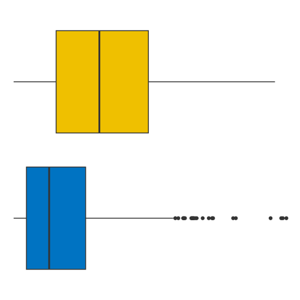

TAT1000

**0.011**

180

1

1.942

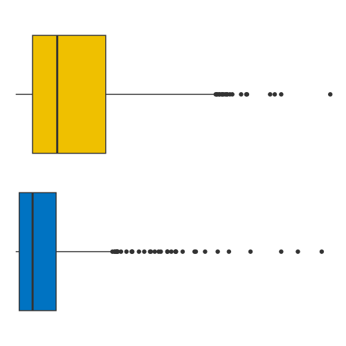

PAT1000

0.15

78

—

—

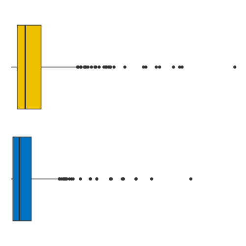

TATd250

**0.003**

410

1

1.772

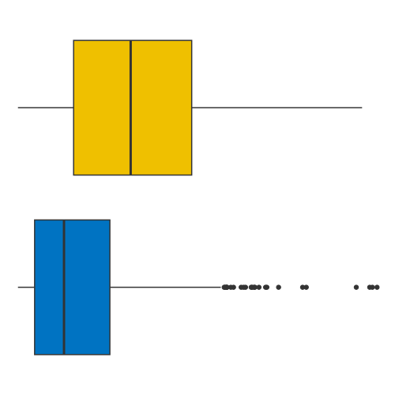

TBTe10

0.9

> 0.9

678

—

—

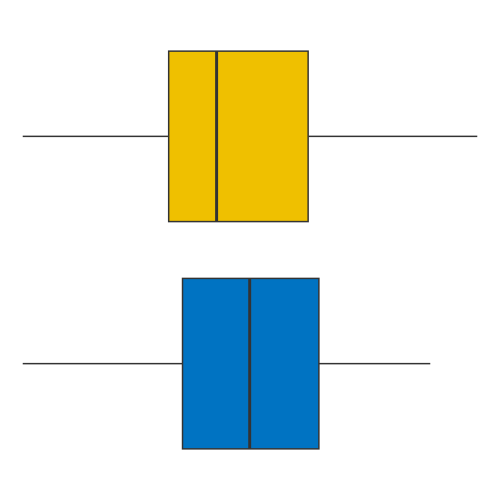

<sup>1</sup> p-values are adjusted for multiple comparisons using the false-discovery-rate for n= 5 comparisons

<sup>2</sup> Model prediction for the intercept per hour of photo- or nighttime period, reference level for the site is Malaysia

<sup>3</sup> Exponentiated beta coefficients from the final model, denoting the multiplication factor for the intercept, conditional on the site

```r
formula_H1 <- value_dc ~ site + (1|site:Id)
formula_H0 <- value_dc ~ 1 + (1|site:Id)

map <- purrr::map

inference_H1 <-
  metrics %>%
  filter(metric %in% metric_selection$H1) %>%
  mutate(data =
           data %>%
           purrr::map(\(x) x %>% mutate(value_dc =
                                   (value/photoperiod_duration) %>% round()))
         )

inference_H1 <-
  inference_H1 %>%
  inference_summary(formula_H1, formula_H0, p_adjustment = p_adjustment$H1,
                    family = poisson())


H1_table <-
Inference_Table(inference_H1, p_adjustment = p_adjustment$H1, value = value_dc)

H1_table <-
H1_table %>%
  tab_footnote(
    "Exponentiated beta coefficients from the final model, denoting the multiplication factor for the intercept, conditional on the site",
    locations = cells_column_labels(columns = c("malaysia", "switzerland"))
  ) %>%
  tab_footnote(
    "Model prediction for the intercept per hour of photo- or nighttime period, reference level for the site is Malaysia",
    locations = cells_column_labels(columns = "Intercept")
  ) %>%
  fmt_duration(columns = Intercept, input_units = "seconds") %>%
  fmt_number("Intercept", decimals = 0) %>%
  fmt_number("switzerland", decimals = 3) %>%
  tab_header(title = "Model Results for Hypothesis 1", )

H1_table
```

```r
v1 <- gt::extract_cells(H1_table, switzerland, 1) %>% as.numeric() %>% round(3)
v2 <- gt::extract_cells(H1_table, switzerland, 2) %>% as.numeric() %>% round(3)
v3 <- gt::extract_cells(H1_table, switzerland, 4) %>% as.numeric() %>% round(3)
```

The model summary shows that swiss participants have significantly more time above threshold for 250 (TAT250) and 1000 lx (TAT1000) than participants in Malaysia, i.e., x1.78 and x1.942, respectively (x1.772 over 250 lx mel EDI during daytime hours, TATd250).

##### 5.2.1.3 Model diagnostics

**TAT250**

```r
Inf_plots1(x, z)
```

[figure not shown]

```r
Inf_plots2(x, z)
```

[figure not shown]

```r
Inf_plots3(x, z, value_dc, "exp")
```

[figure not shown]

**TAT1000**

```r
Inf_plots1(x, z)
```

[figure not shown]

```r
Inf_plots2(x, z)
```

[figure not shown]

```r
Inf_plots3(x, z, value_dc, "exp")
```

[figure not shown]

**PAT1000**

```r
Inf_plots1(x, z)
```

[figure not shown]

```r
Inf_plots2(x, z)
```

[figure not shown]

```r
Inf_plots3(x, z, value_dc, "exp")
```

[figure not shown]

**TATd250**

```r
Inf_plots1(x, z)
```

[figure not shown]

```r
Inf_plots2(x, z)
```

[figure not shown]

```r
Inf_plots3(x, z, value_dc, "exp")
```

[figure not shown]

**TBTe10**

```r
Inf_plots1(x, z)
```

[figure not shown]

```r
Inf_plots2(x, z)
```

[figure not shown]

```r
Inf_plots3(x, z, value_dc, "exp")
```

[figure not shown]

#### 5.2.2 Hypothesis 2

**$H2$**: There are differences in light logger-derived timing of light exposure between Malaysia and Switzerland.

##### 5.2.2.1 Metric calculation

*H2*:

- M10m
- L5m
- IS
- IV
- LLiT 10
- LLiT 250
- Frequency crossing Threshold 250
- mean logarithmic melanopic EDI day & night

```r
metric_selection <- append(metric_selection, list(
    H2_timing = c("M10m", "L5m", "IS", "IV", "LLiT10", "LLiT250", "FcT250"),
  H2_interaction = "mean"
)
)

p_adjustment <- append(
  p_adjustment,
  list(
  H2 = 9
))

metrics <-
  rbind(
    metrics,
      data %>%
  map(
    \(x) {
      #whole-day metrics
      whole_day <-
      x %>%
        group_by(Id, Day) %>%
        summarize(
          .groups = "drop",
          M10m =
            bright_dark_period(
                  MEDI, Datetime, "brightest", "10 hours",
                  as.df = TRUE, na.rm = TRUE
                  ) %>% pull(brightest_10h_mean) %>% log10(),
          L5m =
            bright_dark_period(
                  MEDI, Datetime, "darkest", "5 hours", as.df = TRUE,
                  loop = TRUE, na.rm = TRUE
                  ) %>% pull(darkest_5h_mean) %>% log10(),
          IV = intradaily_variability(MEDI, Datetime),
          LLiT10 =
            timing_above_threshold(
              MEDI, Datetime, "above", 10, as.df = TRUE) %>%
            pull(last_timing_above_10) %>% hms::as_hms() %>% as.numeric(),
          LLiT250 =
            timing_above_threshold(MEDI, Datetime, "above", 250, as.df = TRUE) %>%
            pull(last_timing_above_250) %>% hms::as_hms() %>% as.numeric(),
          FcT250 =
            frequency_crossing_threshold(MEDI, 250, na.rm = TRUE),
        ) %>%
        mutate(across(where(is.duration), as.numeric)) %>%
        pivot_longer(cols = -c(Id, Day), names_to = "metric")

      #part-day metrics
      part_day <-
        x %>%
        group_by(Id, Day, Photoperiod) %>%
        summarize(
          .groups = "drop",
          mean = mean(MEDI, na.rm = TRUE) %>% log10()
        ) %>%
        pivot_longer(cols = -c(Id, Day, Photoperiod), names_to = "metric") %>%
        filter(Photoperiod != "night" & metric == "mean")

      #no-day metrics
      no_day <-
          x %>%
        summarize(IS = interdaily_stability(MEDI, Datetime, na.rm = TRUE)) %>%
        pivot_longer(cols = IS, names_to = "metric")

      whole_day %>%
        bind_rows(part_day, no_day)
    }
  ) %>%
  list_rbind(names_to = "site") %>%
  nest(data = -metric)
  )
```

Hypothesis 2 is analyzed in three distinct ways. The first part is similar to hypothesis 1 but looks at different metrics, that are associated with the timing of light (`Timing`). The second part looks at the possible interaction of light during the day to the evening (`Interaction`). And the third part looks at a model of light across the whole day as a smooth pattern (`Pattern`).

##### 5.2.2.2 Timing

Model Results for Hypothesis 2, Timing

p-value<sup>1</sup>

Intercept

Site coefficients

Malaysia

Switzerland

M10m<sup>2</sup>

**0.004**

2.36

0

0.46

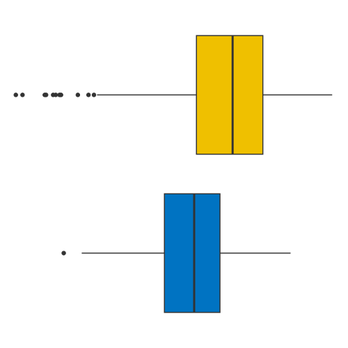

L5m<sup>2</sup>

0.2

−0.88

—

—

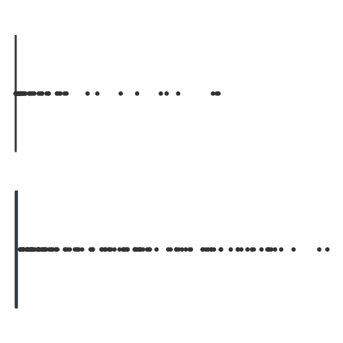

IV

0.9

> 0.9

1.34

—

—

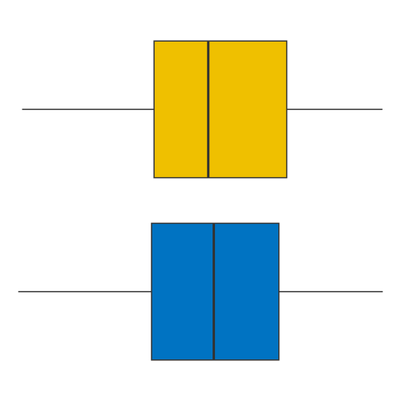

LLiT10

**0.005**

23:16:14

0

−01:10:42

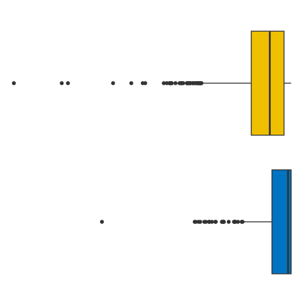

LLiT250

**<0.001**

17:41:23

0

01:27:54

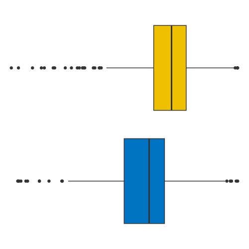

FcT250

**0.005**

35.79

0

28.71

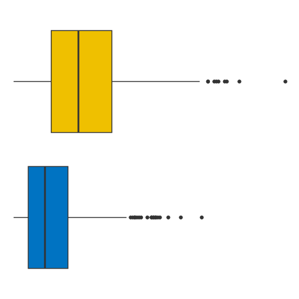

IS

0.9

> 0.9

0.16

—

—

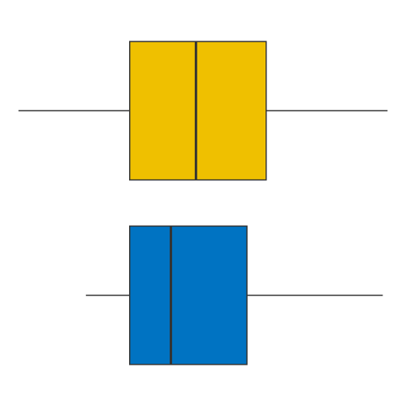

<sup>1</sup> p-values are adjusted for multiple comparisons using the false-discovery-rate for n= 9 comparisons

<sup>2</sup> Values were log10 transformed before model fitting

```r
formula_H2_timing <- value ~ site + (1|site:Id)
formula_H2_IV <- value ~ site
formula_H0 <- value ~ 1 + (1|site:Id)
formula_H0_IV <- value ~ 1

lmer <- lme4::lmer

inference_H2 <-
  metrics %>%
  filter(metric %in% metric_selection$H2_timing) %>%
  mutate(formula_H1 = case_match(metric,
                                 "IS" ~ c(formula_H2_IV),
                                 .default = c(formula_H2_timing)),
         formula_H0 = case_match(metric,
                                 "IS" ~ c(formula_H0_IV),
                                 .default = c(formula_H0)),
         type = (case_match(metric,
                                 "IS" ~ "lm",
                                 .default = "lmer")),
         family = list(gaussian())
         )


inference_H2 <-
  inference_H2 %>%
  inference_summary2(p_adjustment = p_adjustment$H2)

H2_table_timing <-
Inference_Table(inference_H2, p_adjustment = p_adjustment$H2, value = value) %>%
  fmt_number("Intercept", decimals = 2) %>%
  fmt_number("switzerland", decimals = 2) %>%
  cols_align(align = "center", columns = "p.value") %>%
  tab_header(title = "Model Results for Hypothesis 2, Timing", ) %>%
  fmt_duration(columns = c(Intercept, switzerland),
               input_units = "seconds",
               rows = 4:5, duration_style = "colon-sep") %>%
  tab_footnote(
    "Values were log10 transformed before model fitting",
    locations = cells_stub(rows = 1:2)
  )

H2_table_timing
```

```r
v1 <-  gt::extract_cells(H2_table_timing, Intercept, 1) %>% as.numeric()
v2 <-  gt::extract_cells(H2_table_timing, switzerland, 1) %>% as.numeric()
v3 <-  gt::extract_cells(H2_table_timing, switzerland, 4)
v4 <-  gt::extract_cells(H2_table_timing, switzerland, 5)
v5 <-  gt::extract_cells(H2_table_timing, switzerland, 6) %>% as.numeric()
v6 <-  gt::extract_cells(H2_table_timing, Intercept, 6) %>% as.numeric()
```

The model summary shows that the 10 brightest hours (M10m) of swiss participants are significantly brighter than for participants in Malaysia, i.e., an average of 661 lx and 229 lx, respectively and the frequency of crossing 250 lx is about 2 times as high for swiss participants compared to malaysian participants (64 compared to 36, respectively). Swiss participants last time above 250 lx melanopic EDI (LLiT250) is about 1.5 hours later compared to malaysian participants (+01:27:54), and swiss participants avoid values above 10 lx after sundown (LLiT10) about 1 hour earlier compared to malaysia (−01:10:42).

###### 5.2.2.2.1 Model diagnostics

**M10m**

```r
Inf_plots1(x, z)
```

[figure not shown]

```r
Inf_plots2(x, z)
```

[figure not shown]

```r
Inf_plots3(x, z %>% drop_na(value), value, transformation = "identity")
```

[figure not shown]

**L5m**

```r
Inf_plots1(x, z)
```

[figure not shown]

```r
Inf_plots2(x, z)
```

[figure not shown]

```r
Inf_plots3(x, z %>% drop_na(value), value, transformation = "identity")
```

[figure not shown]

**IV**

```r
Inf_plots1(x, z)
```

[figure not shown]

```r
Inf_plots2(x, z)
```

[figure not shown]

```r
Inf_plots3(x, z %>% drop_na(value), value, transformation = "identity")
```

[figure not shown]

**LLiT10**

```r
Inf_plots1(x, z)
```

[figure not shown]

```r
Inf_plots2(x, z)
```

[figure not shown]

```r
Inf_plots3(x, z %>% drop_na(value), value, transformation = "identity")
```

[figure not shown]

**LLiT250**

```r
Inf_plots1(x, z)
```

[figure not shown]

```r
Inf_plots2(x, z)
```

[figure not shown]

```r
Inf_plots3(x, z %>% drop_na(value), value, transformation = "identity")
```

[figure not shown]

**FcT250**

```r
Inf_plots1(x, z)
```

[figure not shown]

```r
Inf_plots2(x, z)
```

[figure not shown]

```r
Inf_plots3(x, z %>% drop_na(value), value, transformation = "identity")
```

[figure not shown]

**IS**

```r
# Inf_plots1(x, z)
Inf_plots2(inference_H2$model[[7]], inference_H2$data[[7]])
```

[figure not shown]

```r
Inf_plots3(inference_H2$model[[7]], inference_H2$data[[7]],
           value, transformation = "identity")
```

[figure not shown]

##### 5.2.2.3 Interaction

Model Results for Hypothesis 2, Interaction

p-value<sup>1,2</sup>

Intercept

Site coefficients

Time coeff.

Interaction coeff.

Malaysia

Switzerland

Day

Evening

Switzerland:Evening

log10(daily mean mel EDI)

**<0.001**

2.23

0

0.41

0

−0.98

−1.11

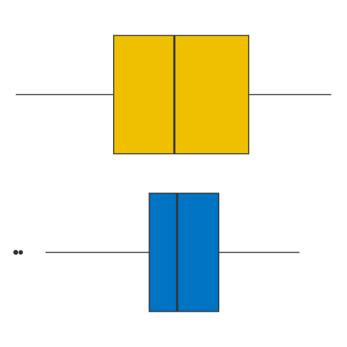

Values were log10 transformed before model fitting

<sup>1</sup> p-values are adjusted for multiple comparisons using the false-discovery-rate for n= 1 comparisons

<sup>2</sup> p-value refers to the interaction effect

```r
formula_H2_interaction <- value ~ site*Photoperiod + (1+Photoperiod|site:Id)
formula_H0_interaction <- value ~ site + Photoperiod + (1+Photoperiod|site:Id)

inference_H2.2 <-
  tibble(metric = "log10(daily mean mel EDI)",
         data = metrics %>% filter(metric == "mean") %>% pull(data)) %>%
  mutate(formula_H1 = c(formula_H2_interaction),
         formula_H0 = c(formula_H0_interaction),
         type = "lmer"
         )

inference_H2.2 <-
  inference_H2.2 %>%
  inference_summary2(p_adjustment = 1)

H2_table_interaction <-
Inference_Table(inference_H2.2, p_adjustment = 1, value = value) %>%
  fmt_number(
    c("Intercept", "switzerland", Photoperiodevening, "switzerland:Photoperiodevening"),
    decimals = 2) %>%
  cols_hide(c("cor__Intercept.Photoperiodevening", "sd__Photoperiodevening")) %>%
  cols_align(align = "center", columns = "p.value") %>%
  tab_header(title = "Model Results for Hypothesis 2, Interaction", ) %>%
  tab_footnote(
    "Values were log10 transformed before model fitting"
  ) %>%
  tab_footnote(
    "p-value refers to the interaction effect",
    locations = cells_column_labels(p.value)
  ) %>%
  cols_label(
    Photoperiodevening = "Evening",
    `switzerland:Photoperiodevening` = "Switzerland:Evening") %>%
  cols_add("Day" = 0, .before = Photoperiodevening) %>%
  tab_spanner("Time coeff.", columns = c(Day, Photoperiodevening)) %>%
  tab_spanner("Interaction coeff.", columns = c(`switzerland:Photoperiodevening`)) %>%
  tab_style(
    style = list(
      cell_text(weight = "bold")
    ),
    locations = cells_column_spanners()
  ) %>%
  tab_style(
    style = list(
      cell_text(weight = "bold")
    ),
    locations = cells_column_labels()
  ) %>%
    tab_style(
      style = cell_text(color = pal_jco()(2)[2]),
      locations = cells_column_labels(c("switzerland:Photoperiodevening"))
    )

H2_table_interaction
```

```r
v1 <-  gt::extract_cells(H2_table_interaction, 3:8) %>% as.numeric()
v2 <- 10^(v1[1]+v1[3]) %>% round(0)
v3 <- 10^(v1[1]+v1[3] + inference_H2.2$summary[[1]]$estimate[3] +
            inference_H2.2$summary[[1]]$estimate[4])  %>% round(1)
v4 <- 10^(v1[1]) %>% round(0)
v5 <- 10^(v1[1] + inference_H2.2$summary[[1]]$estimate[3]) %>% round(1)
```

The model reveals that swiss participants have brighter days and darker evenings compared to the malaysia site. Specifically, model prediction is that a swiss participant has a daily mean melanopic EDI during daytime hours of 437 lx, and 3.5 lx during evening hours. An average malaysian participant reaches a mean 170 lx during daytime, and 17.6 lx during evening hours.

###### 5.2.2.3.1 Model diagnostics

```r
Inf_plots1(inference_H2.2$model[[1]], inference_H2.2$data[[1]])
```

[figure not shown]

```r
Inf_plots2(inference_H2.2$model[[1]], inference_H2.2$data[[1]])
```

[figure not shown]

```r
Inf_plots3(inference_H2.2$model[[1]], inference_H2.2$data[[1]] %>%
             drop_na(value), value, transformation = "identity"
           )
```

[figure not shown]

##### 5.2.2.4 Pattern

###### 5.2.2.4.1 Metric calculation

```r
metrics <-
  rbind(
    metrics,
    data %>%
      map(\(x) {
        x %>%
          select(Id, Datetime, MEDI) %>%
          mutate(Time = hms::as_hms(Datetime) %>% as.numeric() / 3600,
                 Day = date(Datetime) %>% factor(),
                 Id_day = interaction(Id, Day),
                 metric = "MEDI")
      }) %>%
      list_rbind(names_to = "site") %>%
      mutate(site = factor(site)) %>%
      nest(data = -metric)
  )
```

###### 5.2.2.4.2 Model fitting

**adjusted**

```r
formula_H2_pattern <- log10(MEDI) ~ site + s(Time, by = site, bs = "cc", k=12) + s(Id, by = site, bs = "re")

formula_H0_pattern <- log10(MEDI) ~ s(Time, bs = "cc", k = 12) + s(Id, by = site, bs = "re")

#setting the ends for the cyclic smooth
knots_day <- list(Time = c(0, 24))

#Model generation
Pattern_model0 <-
  bam(formula_H0_pattern,
      data = metrics %>% filter(metric == "MEDI") %>% pull(data) %>% .[[1]],
      knots = knots_day,
      samfrac = 0.1,
      discrete = OpenMP_support,
      nthreads = 4,
      control = list(nthreads = 4))

Pattern_model <-
  bam(formula_H2_pattern,
      data = metrics %>% filter(metric == "MEDI") %>% pull(data) %>% .[[1]],
      knots = knots_day,
      samfrac = 0.1,
      nthreads = 4,
      discrete = OpenMP_support,
      control = list(nthreads = 4))

#Model performance
AICs <-
AIC(Pattern_model, Pattern_model0)
AICs
```

```
                     df     AIC
Pattern_model  59.96930 4516274
Pattern_model0 49.97899 4568575
```

```r
Pattern_model_sum <-
summary(Pattern_model)
Pattern_model_sum
```

```
Family: gaussian
Link function: identity

Formula:
log10(MEDI) ~ site + s(Time, by = site, bs = "cc", k = 12) +
    s(Id, by = site, bs = "re")

Parametric coefficients:
                Estimate Std. Error t value Pr(>|t|)
(Intercept)      0.45316    0.05400   8.391   <2e-16 ***
siteswitzerland  0.04480    0.09509   0.471    0.638
---
Signif. codes:  0 '***' 0.001 '**' 0.01 '*' 0.05 '.' 0.1 ' ' 1

Approximate significance of smooth terms:
                           edf Ref.df     F p-value
s(Time):sitemalaysia     9.988     10 37307  <2e-16 ***
s(Time):siteswitzerland  9.993     10 79088  <2e-16 ***
s(Id):sitemalaysia      17.988     18  1623  <2e-16 ***
s(Id):siteswitzerland   18.994     19  2570  <2e-16 ***
---
Signif. codes:  0 '***' 0.001 '**' 0.01 '*' 0.05 '.' 0.1 ' ' 1

R-sq.(adj) =  0.454   Deviance explained = 45.4%
fREML = 2.2583e+06  Scale est. = 1.2648    n = 1469740
```

```r
# plot(Pattern_model)

plot_smooth(
  Pattern_model,
  view = "Time",
  plot_all = "site",
  rug = F,
  n.grid = 90,
  col = pal_jco()(2),
  rm.ranef = "s(Id)",
  sim.ci = TRUE
  )
```

```
Summary:
    * site : factor; set to the value(s): malaysia, switzerland.
    * Time : numeric predictor; with 200 values ranging from 0.000000 to 23.983333.
    * Id : factor; set to the value(s): MY012.
    * NOTE : The following random effects columns are canceled: s(Time):sitemalaysia,s(Time):siteswitzerland,s(Id):sitemalaysia,s(Id):siteswitzerland

    * Simultaneous 95%-CI used :
        Critical value: 2.348
        Proportion posterior simulations in pointwise CI: 0.87 (10000 samples)
        Proportion posterior simulations in simultaneous CI: 0.95 (10000 samples)
```

[figure not shown]

```r
plot_diff(Pattern_model,
          view = "Time",
          rm.ranef = "s(Id)",
          comp = list(site = c("malaysia", "switzerland")),
          sim.ci = TRUE)
```

```
Summary:
    * Time : numeric predictor; with 200 values ranging from 0.000000 to 23.983333.
    * Id : factor; set to the value(s): MY012.
    * NOTE : The following random effects columns are canceled: s(Time):sitemalaysia,s(Time):siteswitzerland,s(Id):sitemalaysia,s(Id):siteswitzerland

    * Simultaneous 95%-CI used :
        Critical value: 2.058
        Proportion posterior simulations in pointwise CI: 1 (10000 samples)
        Proportion posterior simulations in simultaneous CI: 1 (10000 samples)
```

[figure not shown]

```
Time window(s) of significant difference(s):
    0.000000 - 4.097655
    7.351675 - 19.765159
    20.970352 - 23.983333
```

##### 5.2.2.5 Model Diagnostics

```r
gam.check(Pattern_model, rep = 100)
```

[figure not shown]

```
Method: fREML   Optimizer: perf chol
$grad
[1]  2.384107e-06  4.512179e-05  9.560424e-10  3.769323e-07 -4.802411e-05

$hess
           [,1]          [,2]          [,3]          [,4]          [,5]
   4.986919e+00 -3.355115e-25  2.662657e-06 -3.765739e-22     -4.994000
   3.004535e-26  4.991019e+00 -5.625615e-23  4.495121e-07     -4.996344
   2.662657e-06  6.353030e-23  8.987577e+00  7.130559e-20     -8.993804
  -1.189254e-22  4.495121e-07  9.619634e-21  9.488433e+00     -9.497046
d -4.994000e+00 -4.996344e+00 -8.993804e+00 -9.497046e+00 734869.000048

Model rank =  100 / 100

Basis dimension (k) checking results. Low p-value (k-index<1) may
indicate that k is too low, especially if edf is close to k'.

                           k'   edf k-index p-value
s(Time):sitemalaysia    10.00  9.99    0.99    0.12
s(Time):siteswitzerland 10.00  9.99    0.99    0.14
s(Id):sitemalaysia      39.00 17.99      NA      NA
s(Id):siteswitzerland   39.00 18.99      NA      NA
```

**preregistration**

```r
formula_H2_pattern <- log10(MEDI) ~
  site + s(Time, by = site, bs = "cc", k=12) +
  s(Time, by = Id, bs = "cc", k = 12) +
  s(Id, by = site, bs = "re")

formula_H0_pattern <- log10(MEDI) ~
  s(Time, bs = "cc", k = 12) +
  s(Time, by = Id, bs = "cc", k = 12) +
  s(Id, by = site, bs = "re")

formula_Hm1_pattern <- log10(MEDI) ~
  s(Time, by = Id, bs = "cc", k = 12) +
  s(Id, by = site, bs = "re")

#setting the ends for the cyclic smooth
knots_day <- list(Time = c(0, 24))

#Model generation
Pattern_model0 <-
  bam(formula_H0_pattern,
      data = metrics %>% filter(metric == "MEDI") %>% pull(data) %>% .[[1]],
      knots = knots_day,
      samfrac = 0.1,
      discrete = OpenMP_support,
      nthreads = 4,
      control = list(nthreads = 4))

Pattern_modelm1 <-
  bam(formula_Hm1_pattern,
      data = metrics %>% filter(metric == "MEDI") %>% pull(data) %>% .[[1]],
      knots = knots_day,
      samfrac = 0.1,
      discrete = OpenMP_support,
      nthreads = 4,
      control = list(nthreads = 4))

Pattern_modelm2 <-
  bam(formula_H2_pattern,
      data = metrics %>% filter(metric == "MEDI") %>% pull(data) %>% .[[1]],
      knots = knots_day,
      samfrac = 0.1,
      nthreads = 4,
      discrete = OpenMP_support,
      control = list(nthreads = 4))

#Model performance
AICs <-
AIC(Pattern_modelm2, Pattern_model0, Pattern_modelm1)
AICs
```

```
                      df     AIC
Pattern_modelm2 427.2126 4334753
Pattern_model0  427.3398 4334745
Pattern_modelm1 428.0966 4334743
```

```r
Pattern_model_sum <-
summary(Pattern_modelm2)
Pattern_model_sum
```

```
Family: gaussian
Link function: identity

Formula:
log10(MEDI) ~ site + s(Time, by = site, bs = "cc", k = 12) +
    s(Time, by = Id, bs = "cc", k = 12) + s(Id, by = site, bs = "re")

Parametric coefficients:
                Estimate Std. Error t value Pr(>|t|)
(Intercept)      0.45343    0.05409   8.383   <2e-16 ***
siteswitzerland  0.04433    0.09500   0.467    0.641
---
Signif. codes:  0 '***' 0.001 '**' 0.01 '*' 0.05 '.' 0.1 ' ' 1

Approximate significance of smooth terms:
                              edf Ref.df        F p-value
s(Time):sitemalaysia    9.154e+00     10   10.872  <2e-16 ***
s(Time):siteswitzerland 9.966e+00     10 5989.456  <2e-16 ***
s(Time):IdMY001         9.669e+00     10   26.664  <2e-16 ***
s(Time):IdMY002         9.790e+00     10   31.793  <2e-16 ***
s(Time):IdMY003         7.647e+00     10    3.150  <2e-16 ***
s(Time):IdMY004         9.581e+00     10   22.191  <2e-16 ***
s(Time):IdMY005         9.432e+00     10   14.535  <2e-16 ***
s(Time):IdMY007         9.632e+00     10   25.656  <2e-16 ***
s(Time):IdMY008         9.765e+00     10   32.729  <2e-16 ***
s(Time):IdMY009         8.340e+00     10    4.870  <2e-16 ***
s(Time):IdMY010         9.825e+00     10   41.545  <2e-16 ***
s(Time):IdMY011         9.688e+00     10   29.210  <2e-16 ***
s(Time):IdMY012         9.680e+00     10   27.202  <2e-16 ***
s(Time):IdMY013         8.956e+00     10    8.589  <2e-16 ***
s(Time):IdMY014         9.014e+00     10    9.024  <2e-16 ***
s(Time):IdMY015         9.737e+00     10   30.400  <2e-16 ***
s(Time):IdMY016         9.587e+00     10   22.074  <2e-16 ***
s(Time):IdMY017         9.579e+00     10   18.883  <2e-16 ***
s(Time):IdMY018         9.680e+00     10   20.209  <2e-16 ***
s(Time):IdMY019         9.828e+00     10   46.858  <2e-16 ***
s(Time):IdMY020         9.270e+00     10    9.067  <2e-16 ***
s(Time):IdID01          9.885e+00     10  271.241  <2e-16 ***
s(Time):IdID02          9.887e+00     10   92.928  <2e-16 ***
s(Time):IdID03          9.974e+00     10  430.152  <2e-16 ***
```

[output cut: 9 more lines]

```
s(Time):IdID13          9.965e+00     10  334.103  <2e-16 ***
s(Time):IdID14          9.919e+00     10  434.586  <2e-16 ***
s(Time):IdID15          9.853e+00     10  397.519  <2e-16 ***
s(Time):IdID16          1.555e-04     10    0.000  <2e-16 ***
s(Time):IdID17          9.935e+00     10  635.199  <2e-16 ***
s(Time):IdID18          9.819e+00     10  239.344  <2e-16 ***
s(Time):IdID19          9.897e+00     10  265.421  <2e-16 ***
s(Time):IdID20          9.954e+00     10  789.975  <2e-16 ***
s(Id):sitemalaysia      1.799e+01     18 1837.369  <2e-16 ***
s(Id):siteswitzerland   1.899e+01     19 2895.488  <2e-16 ***
---
Signif. codes:  0 '***' 0.001 '**' 0.01 '*' 0.05 '.' 0.1 ' ' 1

R-sq.(adj) =  0.518   Deviance explained = 51.8%
fREML = 2.1686e+06  Scale est. = 1.1176    n = 1469740
```

```r
#Model overview
# plot(Pattern_model, shade = TRUE, residuals = TRUE, cex = 1, all.terms = TRUE)

colors_pattern <- pal_jco()(2)

plot_smooth(
  Pattern_modelm1,
  view = "Time",
  plot_all = "Id",
  rm.ranef = FALSE,
  se = 0,
  rug = F,
  n.grid = 90,
  col = c(rep(colors_pattern[1], 19),rep(colors_pattern[2], 20)),
  # sim.ci = TRUE
  )
```

```
Summary:
    * Time : numeric predictor; with 90 values ranging from 0.000000 to 23.983333.
    * Id : factor with 39 values; set to the value(s): ID01, ID02, ID03, ID04, ID05, ID06, ID07, ID08, ID09, ID10, ...
    * site : factor; set to the value(s): switzerland.
```

[figure not shown]

##### 5.2.2.6 Model Diagnostics

```r
gam.check(Pattern_model)
```

[figure not shown]

```
Method: fREML   Optimizer: perf chol
$grad
[1]  2.384107e-06  4.512179e-05  9.560424e-10  3.769323e-07 -4.802411e-05

$hess
           [,1]          [,2]          [,3]          [,4]          [,5]
   4.986919e+00 -3.355115e-25  2.662657e-06 -3.765739e-22     -4.994000
   3.004535e-26  4.991019e+00 -5.625615e-23  4.495121e-07     -4.996344
   2.662657e-06  6.353030e-23  8.987577e+00  7.130559e-20     -8.993804
  -1.189254e-22  4.495121e-07  9.619634e-21  9.488433e+00     -9.497046
d -4.994000e+00 -4.996344e+00 -8.993804e+00 -9.497046e+00 734869.000048

Model rank =  100 / 100

Basis dimension (k) checking results. Low p-value (k-index<1) may
indicate that k is too low, especially if edf is close to k'.

                           k'   edf k-index p-value
s(Time):sitemalaysia    10.00  9.99    0.99     0.2
s(Time):siteswitzerland 10.00  9.99    0.99     0.2
s(Id):sitemalaysia      39.00 17.99      NA      NA
s(Id):siteswitzerland   39.00 18.99      NA      NA
```

### 5.3 Research Question 2

**RQ 2**: Are there differences in self-reported light exposure patterns using LEBA across time or between the two sites, and if so, in which questions/scores?

As RQ relates to LEBA questions and factors, factors have to be calculated first.

##### 5.3.0.1 Metric calculation

```r
p_adjustment <- append(
  p_adjustment,
  list(
  H3 = 23+5
))


#Factor calculation
factors_leba <- list(
  F1 = names(leba_questions)[c(1,2,3)],
  F2 = names(leba_questions)[c(4:9)],
  F3 = names(leba_questions)[c(10:14)],
  F4 = names(leba_questions)[c(15:18)],
  F5 = names(leba_questions)[c(19:23)]
)
Fs <- paste0("F", 1:5)

leba_data_combined <-
leba_data_combined %>%
  mutate(leba_F2_04 = fct_rev(leba_F2_04),
         leba_F1 = rowSums(across(contains(factors_leba$F1), as.numeric)),
         leba_F2 = rowSums(across(contains(factors_leba$F2), as.numeric)),
         leba_F3 = rowSums(across(contains(factors_leba$F3), as.numeric)),
         leba_F4 = rowSums(across(contains(factors_leba$F4), as.numeric)),
         leba_F5 = rowSums(across(contains(factors_leba$F5), as.numeric)),
         ) %>%
  mutate(leba_F2_04 = fct_rev(leba_F2_04),
         across(c(site, Id), factor))

leba_factors <- c(
  leba_F1 = "Wearing blue light filtering glasses indoors and outdoors",
  leba_F2 = "Spending time outdoors",
  leba_F3 = "Using phones and smartwatches in bed before sleep",
  leba_F4 = "Controlling and using ambient light before bedtime",
  leba_F5 = "Using light in the morning and during daytime"
)

#set variable labels
var_label(leba_data_combined) <- leba_factors %>% as.list()

leba_metrics <-
  leba_data_combined %>%
  mutate(across(contains("leba_F"), as.numeric)) %>%
  pivot_longer(cols = starts_with("leba_F"), names_to = "metric", values_to = "value") %>%
  nest(data = -metric)

leba_metrics <-
leba_metrics %>%
  rowwise() %>%
  mutate(data = list({
    if(str_length(metric) == 7) data
    else data %>% mutate(value = factor(value, levels = 1:5, labels = leba_levels))
  }
  ))
```

#### 5.3.1 Hypothesis 3

**$H3$**: There are differences in LEBA items and factors between Malaysia and Switzerland.

##### 5.3.1.1 Model fitting

**Items**

###### 5.3.1.1.1 Whole Dataset

```r
formula_H3 <- value ~ site + (1|site:Id)
formula_H0 <- value ~ 1 + (1|site:Id)

clmm <- ordinal::clmm

inference_H3 <-
leba_metrics %>%
  filter(str_length(metric) != 7) %>%
  mutate(formula_H1 = c(formula_H3),
         formula_H0 = c(formula_H0),
         type = "clmm")

inference_H3 <-
  inference_H3 %>%
    rowwise() %>%
    mutate(
      model =
        list(
            do.call(type, list(formula = formula_H1,
                                          data = data,
                               nAGQ = 5))
            ),
      model0 = list(
        do.call(type, list(formula = formula_H0,
                           data = data,
                           nAGQ = 5))
      ))

inference_H3$comparison <- vector("list", nrow(inference_H3))

for(i in 1:nrow(inference_H3)) {
  comparison <- anova(inference_H3$model[[i]], inference_H3$model0[[i]])
  inference_H3$comparison[[i]] <- comparison
}

inference_H3 <-
inference_H3 %>%
  mutate(
      p.value_adj = comparison$`Pr(>Chisq)` %>% .[2] %>%
        p.adjust(method = "fdr", n = p_adjustment$H3),
      significant = p.value_adj <= 0.05,
      summary = list(
        switch(significant+1,
               tidy(model0),
               tidy(model))),
    table = list(
        tibble(
          metric = metric,
          p.value =
            p.value_adj %>%
            style_pvalue() %>%
            {ifelse(significant, paste0("**", ., "**"),.)},
          summary %>%
            mutate(estimate = estimate) %>%
            select(term, estimate) %>%
            filter(term != "sd__(Intercept)" &
                     term != "sd__Observation") %>%
            mutate(term = str_remove_all(term, "\\(|\\)|site")) %>%
            pivot_wider(names_from = term, values_from = estimate)
        ) %>%
          mutate(malaysia = if(exists("switzerland")) 0 else NA)
  )
  )

inference_H3 %>% pull(table) %>% list_rbind() %>% select(metric, p.value) %>% gt()
```

| metric | p.value |
| --- | --- |
| leba_F1_01 | >0.9 |
| leba_F1_02 | >0.9 |
| leba_F1_03 | >0.9 |
| leba_F2_04 | >0.9 |
| leba_F2_05 | >0.9 |
| leba_F2_06 | >0.9 |
| leba_F2_07 | >0.9 |
| leba_F2_08 | >0.9 |
| leba_F2_09 | 0.8 |
| leba_F3_10 | >0.9 |
| leba_F3_11 | >0.9 |
| leba_F3_12 | 0.7 |
| leba_F3_13 | >0.9 |
| leba_F3_14 | >0.9 |
| leba_F4_15 | >0.9 |
| leba_F4_16 | >0.9 |
| leba_F4_17 | 0.5 |
| leba_F4_18 | >0.9 |
| leba_F5_19 | >0.9 |
| leba_F5_20 | 0.9 |
| leba_F5_21 | >0.9 |
| leba_F5_22 | 0.3 |
| leba_F5_23 | >0.9 |

Under the strict p-value adjustment for H3 (n=28), none of the behavioral questions are significantly different.

###### 5.3.1.1.2 Only last collection point

```r
formula_H3 <- value ~ site
formula_H0 <- value ~ 1

clmm <- ordinal::clmm
clm <- ordinal::clm

inference_H3.2 <-
leba_metrics %>%
  filter(str_length(metric) != 7) %>%
  mutate(formula_H1 = c(formula_H3),
         formula_H0 = c(formula_H0),
         type = "clm",
         data = list(data %>% filter(Day == 31)))

inference_H3.2 <-
  inference_H3.2 %>%
    rowwise() %>%
    mutate(
      model =
        list(
            do.call(type, list(formula = formula_H1,
                                          data = data))
            ),
      model0 = list(
        do.call(type, list(formula = formula_H0,
                           data = data))
      ))

inference_H3.2$comparison <- vector("list", nrow(inference_H3.2))

for(i in 1:nrow(inference_H3.2)) {
  comparison <- anova(inference_H3.2$model[[i]], inference_H3.2$model0[[i]])
  inference_H3.2$comparison[[i]] <- comparison
}

inference_H3.2 <-
inference_H3.2 %>%
  mutate(
      p.value_adj = comparison$`Pr(>Chisq)` %>% .[2] %>%
        p.adjust(method = "fdr", n = p_adjustment$H3),
      significant = p.value_adj <= 0.05,
      summary = list(
        switch(significant+1,
               tidy(model0),
               tidy(model))),
    table = list(
        tibble(
          metric = metric,
          p.value =
            p.value_adj %>%
            style_pvalue() %>%
            {ifelse(significant, paste0("**", ., "**"),.)},
          summary %>%
            mutate(estimate = estimate) %>%
            select(term, estimate) %>%
            filter(term != "sd__(Intercept)" &
                     term != "sd__Observation") %>%
            mutate(term = str_remove_all(term, "\\(|\\)|site")) %>%
            pivot_wider(names_from = term, values_from = estimate)
        ) %>%
          mutate(malaysia = if(exists("switzerland")) 0 else NA)
  )
  )

inference_H3.2 %>% pull(table) %>% list_rbind() %>% select(metric, p.value) %>% gt()
```

| metric | p.value |
| --- | --- |
| leba_F1_01 | >0.9 |
| leba_F1_02 | >0.9 |
| leba_F1_03 | >0.9 |
| leba_F2_04 | >0.9 |
| leba_F2_05 | >0.9 |
| leba_F2_06 | >0.9 |
| leba_F2_07 | >0.9 |
| leba_F2_08 | >0.9 |
| leba_F2_09 | >0.9 |
| leba_F3_10 | >0.9 |
| leba_F3_11 | >0.9 |
| leba_F3_12 | 0.055 |
| leba_F3_13 | >0.9 |
| leba_F3_14 | >0.9 |
| leba_F4_15 | >0.9 |
| leba_F4_16 | >0.9 |
| leba_F4_17 | >0.9 |
| leba_F4_18 | >0.9 |
| leba_F5_19 | >0.9 |
| leba_F5_20 | >0.9 |
| leba_F5_21 | >0.9 |
| leba_F5_22 | >0.9 |
| leba_F5_23 | >0.9 |

**Factors**

```r
formula_H3 <- value ~ site + (1|site:Id)
formula_H0 <- value ~ 1 + (1|site:Id)

inference_H3.3 <-
  leba_metrics %>%
  filter(str_length(metric) == 7) %>%
  mutate(formula_H1 = c(formula_H3),
         formula_H0 = c(formula_H0),
         type = "lmer",
         family = list(poisson())
         )

inference_H3.3 <-
  inference_H3.3 %>%
  inference_summary2(p_adjustment = p_adjustment$H3)

inference_H3.3 %>% pull(table) %>% list_rbind() %>% select(metric, p.value) %>% gt()
```

| metric | p.value |
| --- | --- |
| leba_F1 | >0.9 |
| leba_F2 | >0.9 |
| leba_F3 | >0.9 |
| leba_F4 | >0.9 |
| leba_F5 | >0.9 |

Under the strict p-value adjustment for H3 (n=28), none of the behavioral factors are significantly different between sites.

###### 5.3.1.1.3 Model diagnostics

**leba_F1**

```r
Inf_plots1(x, z)
```

[figure not shown]

```r
Inf_plots2(x, z)
```

[figure not shown]

```r
Inf_plots3(x, z, value, "identity")
```

[figure not shown]

**leba_F2**

```r
Inf_plots1(x, z)
```

[figure not shown]

```r
Inf_plots2(x, z)
```

[figure not shown]

```r
Inf_plots3(x, z, value, "identity")
```

[figure not shown]

**leba_F3**

```r
Inf_plots1(x, z)
```

[figure not shown]

```r
Inf_plots2(x, z)
```

[figure not shown]

```r
Inf_plots3(x, z, value, "identity")
```

[figure not shown]

**leba_F4**

```r
Inf_plots1(x, z)
```

[figure not shown]

```r
Inf_plots2(x, z)
```

[figure not shown]

```r
Inf_plots3(x, z, value, "identity")
```

[figure not shown]

**leba_F5**

```r
Inf_plots1(x, z)
```

[figure not shown]

```r
Inf_plots2(x, z)
```

[figure not shown]

```r
Inf_plots3(x, z, value, "identity")
```

[figure not shown]

#### 5.3.2 Hypothesis 4

**$H4$**: LEBA scores vary over time within participants

For this hypothesis, only the malaysian data is used, as specified in the preregistration document.

Model Results for Hypothesis 4

Item/Factor

Metric code

Participants with significant variation<sup>1</sup>

stable over time in 75-100% of participants

I look at my smartwatch when I wake up at night

leba_F3_14

0.00%

I wear blue-filtering, orange-tinted, and/or red-tinted glasses indoors during the day

leba_F1_01

5.26%

[figure not shown]

I wear blue-filtering, orange-tinted, and/or red-tinted glasses within 1 hour before attempting to fall asleep

leba_F1_03

5.26%

I use my mobile phone within 1 hour before attempting to fall asleep

leba_F3_10

5.26%

[figure not shown]

I look at my smartwatch within 1 hour before attempting to fall asleep

leba_F3_13

5.26%

I wear blue-filtering, orange-tinted, and/or red-tinted glasses outdoors during the day

leba_F1_02

10.53%

[figure not shown]

I go for a walk or exercise outside within 2 hours after waking up

leba_F2_09

10.53%

[figure not shown]

Wearing blue light filtering glasses indoors and outdoors

leba_F1

10.53%

[figure not shown]

I use a desk lamp when I do focused work

leba_F5_21

15.79%

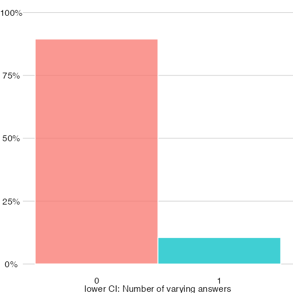

I use an alarm with a dawn simulation light

leba_F5_22

21.05%

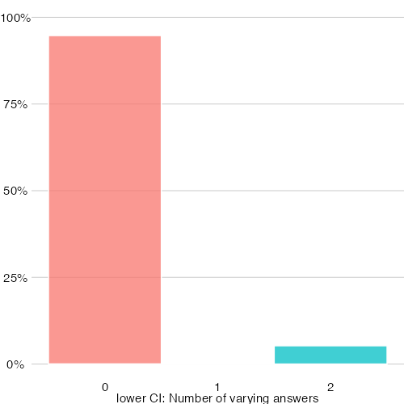

stable over time in 50-75% of participants

I spend between 30 minutes and 1 hour per day (in total) outside

leba_F2_05

26.32%

[figure not shown]

I use a blue-filter app on my computer screen within 1 hour before attempting to fall asleep

leba_F4_16

26.32%

[figure not shown]

I use tunable lights to create a healthy light environment

leba_F5_19

26.32%

I spend between 1 and 3 hours per day (in total) outside

leba_F2_06

31.58%

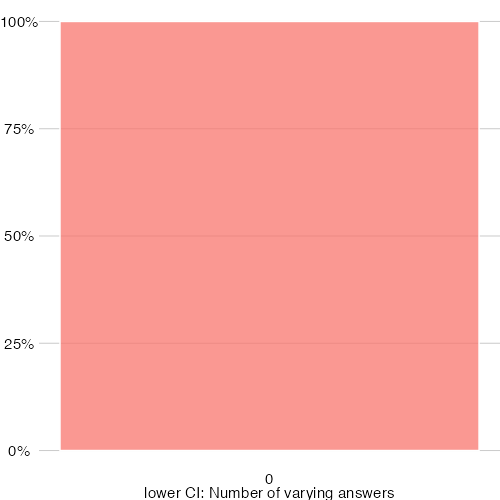

I spend as much time outside as possible

leba_F2_08

31.58%

[figure not shown]

I use LEDs to create a healthy light environment

leba_F5_20

31.58%

I spend more than 3 hours per day (in total) outside

leba_F2_07

36.84%

[figure not shown]

I look at my mobile phone screen immediately after waking up

leba_F3_11

36.84%

[10 more figures not shown]

<sup>1</sup> based on 10000 bootstraps of individual participants answers across the four weeks of data collection. If the lower threshold for a 95% confidence interval is above 0, the participant is considered to have significant variation in their answers.

```r
bootstraps <- 10^4

leba_metrics_H4 <-
leba_metrics %>%
  mutate(data = list(data %>% filter(site == "malaysia")))

boot_plot <- function(data) {
  data %>%
  ggplot(aes(x = CI95lower/(1/3))) +
  geom_histogram(aes(fill = CI95lower/(1/3) >= 0.5), binwidth = 1, col = "white", alpha = 0.75) +
  scale_x_continuous(breaks = c(0:10)) +
  theme_void() +
  labs(x = "lower CI: Number of varying answers", y = "Frequency")+
  theme(axis.text = element_text(),
        legend.position = "none",
        axis.title.x = element_text(),
        panel.grid.major.y = element_line(colour = "grey80")) +
  scale_y_continuous(labels = scales::label_percent(scale = 100/19),
                     breaks = c(0, 50/100*19, 25/100*19, 75/100*19, 100/100*19))+
  coord_cartesian(ylim = c(0, 100/100*19))
}

leba_metrics_H4 <-
  leba_metrics_H4 %>%
  rowwise() %>%
  mutate(bootstrap =
           list(data %>%
               select(Id, value) %>%
               mutate(value = as.numeric(value)) %>%
               expand_grid(bootstrap = seq(bootstraps)) %>%
               group_by(Id, bootstrap) %>%
               slice_sample(prop = 1, replace = TRUE) %>%
               summarize(sd = stats::sd(value), .groups = "drop_last") %>%
               summarize(
                 mean_sd = mean(sd),
                 CI95lower = quantile(sd, 0.025),
                 CI95_upper = quantile(sd, 0.975),
                 .groups = "drop_last"
               ) %>%
               mutate(significant = ifelse(CI95lower == 0, FALSE, TRUE)) %>%
               summarize(
                 percent_significant = mean(significant),
                 plot = list(tibble(CI95lower) %>% boot_plot())
               )
           )
         )

labels_leba <-
var_label(leba_data_combined)[-c(1:3)] %>% enframe() %>% unnest(value)

leba_results_H4 <-
  leba_metrics_H4 %>%
  unnest(bootstrap) %>%
  select(-data) %>%
  left_join(labels_leba, by = c("metric" = "name")) %>%
  rename(question = value) %>%
  group_by(quartile =
             cut(
               percent_significant,
               breaks = c(-0.1, 0.25, 0.5, 0.75, 1.1),
               labels =
                 paste(
                   "stable over time in",
                   c("75-100%", "50-75%", "25-50%", "25-0%"),
                   "of participants"
                 )
             ))

leba_results_H4 %>%
  relocate(question, .before = 1) %>%
  arrange(percent_significant) %>%
  gt() %>%
  text_transform(
    locations = cells_body(columns = plot),
    fn = function(x)
      leba_results_H4$plot %>% ggplot_image(height = px(200))
  ) %>%
  fmt_percent(columns = percent_significant) %>%
  cols_label(plot = "",
             percent_significant = "Participants with significant variation",
             question = "Item/Factor",
             metric = "Metric code") %>%
  cols_align(align = "center", columns = -question) %>%
  tab_footnote(
    paste(
      "based on",
      bootstraps,
      "bootstraps of individual participants answers across the four weeks of data collection. If the lower threshold for a 95% confidence interval is above 0, the participant is considered to have significant variation in their answers."
    ),
    locations = cells_column_labels(columns = "percent_significant")
  ) %>%
  tab_header(title = "Model Results for Hypothesis 4") %>%
  tab_style(
    style = cell_text(weight = "bold"),
    locations = list(cells_column_labels(), cells_stub())
  )
```

```r
leba_H4_table <-
leba_results_H4 %>% select(metric, quartile) %>% nest(data = metric) %>%
  arrange(quartile) %>%
  mutate(data = map(data, ~.x %>% pull(metric) %>% paste(collapse = ", "))) %>%
  unnest(data) %>%
  mutate(data = str_replace_all(data, "leba_F", "Factor "),
         data = str_replace_all(data, "_", ": Item ")) %>%
  gt() %>%
  tab_style(
    style = cell_text(weight = "bold"),
    locations = cells_row_groups()
  ) %>%
  tab_options(column_labels.hidden = TRUE) %>%
  tab_header(title = "Hypothesis 4: Extent of stable LEBA items and factors over time")

leba_H4_table
```

Hypothesis 4: Extent of stable LEBA items and factors over time

| stable over time in 75-100% of participants |
| --- |
| Factor 1: Item 01, Factor 1: Item 02, Factor 1: Item 03, Factor 2: Item 09, Factor 3: Item 10, Factor 3: Item 13, Factor 3: Item 14, Factor 5: Item 21, Factor 5: Item 22, Factor 1 |
| stable over time in 50-75% of participants |
| Factor 2: Item 04, Factor 2: Item 05, Factor 2: Item 06, Factor 2: Item 07, Factor 2: Item 08, Factor 3: Item 11, Factor 3: Item 12, Factor 4: Item 15, Factor 4: Item 16, Factor 4: Item 17, Factor 4: … |
| stable over time in 25-50% of participants |
| Factor 5 |
| stable over time in 25-0% of participants |
| Factor 2, Factor 3, Factor 4 |

```r
leba_H4_table %>% gtsave("figures/Table_H4.png")

v1 <- leba_results_H4 %>% summarize(length = n())
```

```r
#average change
leba_changes <-
leba_metrics %>%
  mutate(data = list(data %>% filter(site == "malaysia")),
         data = list(data %>% mutate(value = as.numeric(value)) %>%
                       group_by(Id) %>%
                       summarize(sd = stats::sd(value), mean = mean(value),
                                 cv = sd/mean, .groups = "drop_last") %>%
                       summarize(mean_sd = mean(sd),
                                 mean_cv = mean(cv))))

leba_changes %>% unnest(data) %>% select(metric, mean_sd) %>%
  mutate(average_change = mean_sd/(1/3),
         average_change = average_change %>% round()) %>%
  left_join(labels_leba, by = c("metric" = "name")) %>%
  relocate(question = value, .before = 1) %>%
  gt() %>%
  fmt_number(columns = mean_sd, decimals = 2) %>%
    tab_style(
    style = cell_text(weight = "bold"),
    locations = cells_column_labels()
  ) %>%
  cols_label(
             question = "Item/Factor",
             metric = "Metric code",
             mean_sd = "SD",
             average_change = "Average change") %>%
  tab_footnote(
    "Average standard deviation across participants",
    locations = cells_column_labels(columns = "mean_sd")
  ) %>%
  tab_footnote(
        "Average change in scores total across the four weeks of data collection. A value of 1 indicates that across the 9 times of data collection, only once did a participant's score change by 1 point. A value of 2 indicates a score change once by 2 points, or two times by 1, and so forth.",
    locations = cells_column_labels(columns = "average_change")
  ) %>%
  tab_header(title = "Average change in LEBA metrics across four weeks of data collection")
```

Average change in LEBA metrics across four weeks of data collection

| Item/Factor | Metric code | SD<sup>1</sup> | Average change<sup>2</sup> |
| --- | --- | --- | --- |
| I wear blue-filtering, orange-tinted, and/or red-tinted glasses indoors during the day | leba_F1_01 | 0.10 | 0 |
| I wear blue-filtering, orange-tinted, and/or red-tinted glasses outdoors during the day | leba_F1_02 | 0.18 | 1 |
| I wear blue-filtering, orange-tinted, and/or red-tinted glasses within 1 hour before attempting to fall asleep | leba_F1_03 | 0.09 | 0 |
| I spend 30 minutes or less per day (in total) outside | leba_F2_04 | 0.57 | 2 |
| I spend between 30 minutes and 1 hour per day (in total) outside | leba_F2_05 | 0.54 | 2 |
| I spend between 1 and 3 hours per day (in total) outside | leba_F2_06 | 0.46 | 1 |
| I spend more than 3 hours per day (in total) outside | leba_F2_07 | 0.51 | 2 |
| I spend as much time outside as possible | leba_F2_08 | 0.39 | 1 |
| I go for a walk or exercise outside within 2 hours after waking up | leba_F2_09 | 0.24 | 1 |
| I use my mobile phone within 1 hour before attempting to fall asleep | leba_F3_10 | 0.27 | 1 |
| I look at my mobile phone screen immediately after waking up | leba_F3_11 | 0.46 | 1 |
| I check my phone when I wake up at night | leba_F3_12 | 0.57 | 2 |
| I look at my smartwatch within 1 hour before attempting to fall asleep | leba_F3_13 | 0.08 | 0 |
| I look at my smartwatch when I wake up at night | leba_F3_14 | 0.07 | 0 |
| I dim my mobile phone screen within 1 hour before attempting to fall asleep | leba_F4_15 | 0.62 | 2 |
| I use a blue-filter app on my computer screen within 1 hour before attempting to fall asleep | leba_F4_16 | 0.27 | 1 |
| I use as little light as possible when I get up during the night | leba_F4_17 | 0.70 | 2 |
| I dim my computer screen within 1 hour before attempting to fall asleep | leba_F4_18 | 0.55 | 2 |
| I use tunable lights to create a healthy light environment | leba_F5_19 | 0.28 | 1 |
| I use LEDs to create a healthy light environment | leba_F5_20 | 0.49 | 1 |
| I use a desk lamp when I do focused work | leba_F5_21 | 0.25 | 1 |
| I use an alarm with a dawn simulation light | leba_F5_22 | 0.19 | 1 |
| I turn on the lights immediately after waking up | leba_F5_23 | 0.54 | 2 |
| Wearing blue light filtering glasses indoors and outdoors | leba_F1 | 0.32 | 1 |
| Spending time outdoors | leba_F2 | 1.40 | 4 |
| Using phones and smartwatches in bed before sleep | leba_F3 | 1.03 | 3 |
| Controlling and using ambient light before bedtime | leba_F4 | 1.33 | 4 |
| Using light in the morning and during daytime | leba_F5 | 1.28 | 4 |

<sup>1</sup> Average standard deviation across participants  
<sup>2</sup> Average change in scores total across the four weeks of data collection. A value of 1 indicates that across the 9 times of data collection, only once did a participant's score change by 1 point. A value of 2 indicates a score change once by 2 points, or two times by 1, and so forth.

### 5.4 Research Question 3

**RQ 3** In general, how are light exposure and LEBA related and are there differences in this relationship between the two sites?

##### 5.4.0.1 Metric calculation

Additional metrics need to be calculated:

- First time above threshold 250 lx mel EDI (FLiT250)
- First time above threshold 1000 lx mel EDI (FLiT1000)
- L5 without sleep period (night), i.e. day and evening (L5mde)
- L5 only night time (L5mn)
- Melanopic/photopic ratio (MPratio)
- Light exposure (dose of light) for melanopic EDI (LE)
- Spectral contribution to melanopic EDI (SCmelEDI) [^1]

```r
p_adjustment <- append(
  p_adjustment,
  list(
  H5 = 2*84,
  H6 = 23+5
))

metrics <-
  rbind(
    metrics,
    data %>%
map(
  \(x) {
      #whole-day metrics
      whole_day <-
      x %>%
        group_by(Id, Day) %>%
        summarize(
          .groups = "drop",
          FLiT1000 =
            timing_above_threshold(
              MEDI, Datetime, "above", 1000, as.df = TRUE) %>%
            pull(first_timing_above_1000) %>% hms::as_hms() %>% as.numeric(),
          FLiT250 =
            timing_above_threshold(MEDI, Datetime, "above", 250, as.df = TRUE) %>%
            pull(first_timing_above_250) %>% hms::as_hms() %>% as.numeric(),
          MPratio = mean(MEDI, na.rm = TRUE)/mean(Photopic.lux, na.rm = TRUE),
          LE = sum(MEDI, na.rm = TRUE)/60,
          SCmelEDI = mean(MEDI, na.rm = TRUE)/753.35/
            mean(rowSums(across(starts_with("WL_")))*1000, na.rm = TRUE)
        ) %>%
        mutate(across(where(is.duration), as.numeric)) %>%
        pivot_longer(cols = -c(Id, Day), names_to = "metric")

      #part-day metrics
      part_day <-
        x %>%
        group_by(Id, Day, Night = Photoperiod == "night") %>%
        summarize(
          .groups = "drop",
          L5m =
            bright_dark_period(
                  MEDI, Datetime, "darkest", "5 hours", as.df = TRUE,
                  na.rm = TRUE
                  ) %>% pull(darkest_5h_mean) %>% log10()
        ) %>%
        pivot_longer(cols = -c(Id, Day, Night), names_to = "metric") %>%
        mutate(metric = case_when(
          metric == "L5m" & Night == TRUE ~ "L5mn",
          metric == "L5m" & Night == FALSE ~ "L5mde"
        ))

      whole_day %>%
        bind_rows(part_day)
    }
  ) %>%
  list_rbind(names_to = "site") %>%
  nest(data = -metric)
  )

#nest the datasets by site
metricsRQ3 <-
  metrics %>%
  rowwise() %>%
  mutate(data = list(data %>%
                       mutate(across(any_of("Day"), as_date))
                     )
         ) %>%
  unnest(data) %>%
  nest(data = -c(site, metric)) %>%
  nest(data = -site)

#select relevant metrics by question
metric_selection$H5 <-
  list(
    leba_F1_01 = c(),
    leba_F1_02 = c(),
    leba_F1_03 = c(),
    leba_F2_04 = c("M10m", "TAT250", "TAT1000", "PAT1000", "IV", "IS"),
    leba_F2_05 = c("M10m", "TAT250", "TAT1000", "PAT1000", "IV", "IS"),
    leba_F2_06 = c("M10m", "TAT250", "TAT1000", "PAT1000", "IV", "IS"),
    leba_F2_07 = c("M10m", "TAT250", "TAT1000", "PAT1000", "IV", "IS"),
    leba_F2_08 = c("M10m", "TAT250", "TAT1000", "PAT1000", "IV", "IS"),
    leba_F2_09 = c("FLiT1000", "IV", "IS"),
    leba_F3_10 = c("LLiT10", "LLiT250", "L5mn", "IV", "IS"),
    leba_F3_11 = c("FLiT250", "IV", "IS"),
    leba_F3_12 = c("L5m", "IV", "IS"),
    leba_F3_13 = c("LLiT10", "LLiT250", "L5mn", "IV", "IS"),
    leba_F3_14 = c("L5m", "IV", "IS"),
    leba_F4_15 = c("LLiT10", "LLiT250", "L5mde", "IV", "IS"),
    leba_F4_16 = c("LLiT10", "LLiT250", "L5mde", "IV", "IS"),
    leba_F4_17 = c("L5m", "L5mn", "IV", "IS"),
    leba_F4_18 = c("LLiT10", "LLiT250", "L5mde", "IV", "IS"),
    leba_F5_19 = c("IV", "IS", "L5mn", "L5mde", "M10m"),
    leba_F5_20 = c("LE", "SCmelEDI", "MPratio"),
    leba_F5_21 = c("LE"),
    leba_F5_22 = c("SCmelEDI", "FLiT10", "FLiT250"),
    leba_F5_23 = c("SCmelEDI", "FLiT10", "FLiT250")
  )

#transform relevant metrics to a table of metrics
metric_selectionH5 <-
metric_selection$H5 %>%
  enframe() %>%
  unnest(value) %>%
  mutate(hypothesised = TRUE)
```

#### 5.4.1 Hypothesis 5

**$H5$**: LEBA items correlate with preselected light-logger derived light exposure variables.

Due to how the LEBA questions were phrased, different timespan comparisons are needed. For Malaysia, only the last instance is used and average metric values are calculated from daily data. For Switzerland, respective time periods are compared to one another, i.e. a LEBA period of 4 days is compared to the light exposure metrics from the same 4 days, and averaged over those days for a one-to-one comparison.

**Malaysia**

```r
#collect the light exposure data for malaysia
metrics_H5_malaysia <-
  metricsRQ3 %>%
  filter(site == "malaysia") %>%
  unnest(data) %>%
  select(-site) %>%
  filter(metric != "mean")

#average values across all days
metrics_H5_malaysia <-
  metrics_H5_malaysia %>%
  rowwise() %>%
  mutate(data = list(data %>%
                       group_by(Id) %>%
                       summarize(value = mean(value, na.rm = TRUE), .groups = "drop")
  )
  )

#collect the appropriate day for the LEBA data
leba_H5_malaysia <-
  leba_data_combined %>% filter(site == "malaysia", Day ==31) %>%
  select(-Datetime, -site, -Day) %>%
    mutate(across(-Id, as.numeric)) %>%
  pivot_longer(cols = -Id, names_to = "leba", values_to = "leba_values")

#join the data
leba_light_H5_malaysia <-
metrics_H5_malaysia %>%
  unnest(data) %>%
  rename(metric_value = value) %>%
  left_join(leba_H5_malaysia, by = "Id",
            relationship = "many-to-many") %>%
  select(-Id) %>%
  drop_na()

#calculate correlations
corr_malaysia <-
  leba_light_H5_malaysia %>%
    group_by(metric, leba) %>%
    summarize(
      correlation = cor(metric_value, leba_values, method = "spearman"),
              p_value = cor.test(metric_value, leba_values)$p.value,
              p_value_adjusted =p.adjust(p_value, method = "fdr",
                                         n = p_adjustment$H5),
              significant = p_value <= 0.05,
              significant_adjusted = p_value_adjusted <= 0.05,
              .groups = "drop") %>%
  mutate(
    question = leba_questions[leba],
    factor = leba_factors[leba],
    question = ifelse(is.na(question), factor, question),
    .before = 1) %>%
  fill(factor) %>%
  left_join(metric_selectionH5, by = c("metric" = "value", "leba" = "name")) %>%
  mutate(hypothesised = ifelse(is.na(hypothesised), FALSE, hypothesised),
         coloring = case_when(
           significant_adjusted & hypothesised ~ "Hypothesised and significant",
           significant & hypothesised ~ "Hypothesised and (unadjusted) significant",
           significant & !hypothesised ~ "(unadjusted) Significant",
           !significant_adjusted & hypothesised ~ "Hypothesised",
           TRUE ~ "None"
         ) %>% factor(levels = c("Hypothesised and significant", "Hypothesised and (unadjusted) significant", "(unadjusted) Significant", "Hypothesised", "None")
         )
         ) %>%
    mutate(
    leba = leba %>%
        str_remove("leba_") %>%
        str_replace("_", ", ") %>%
        str_replace("(F[:digit:])$", "\\1 (overall)")
  )

colors_H5 <- c("gold", "orange", "white", "red", "grey")


#display the results
corr_plot_malaysia <-
corr_malaysia %>%
  ggplot(aes(x = metric, y = (leba %>% factor() %>% fct_rev()), fill = abs(correlation), col = coloring)) +
  geom_blank()+
  geom_tile(data = corr_malaysia %>% filter(coloring != "None"), linewidth = 0.25) +
  geom_text(
    aes(label =
          paste(
            paste("c=",round(correlation, 2)),
            p_value %>% style_pvalue(prepend_p = TRUE),
            sep = "\n")
        ),
    fontface = "bold",
    size = 1.8) +
  coord_fixed() +
  scale_fill_viridis_c(limits = c(0,1))+
  scale_color_manual(values = colors_H5, drop = FALSE)+
  labs(y = "LEBA questions and factors", x = "Metrics", color = "Relevance",
       fill = "(abs) Correlation", subtitle = "Malaysia")+
  theme(axis.text.x = element_text(angle = 90, hjust = 1),
        plot.subtitle = element_text(color = pal_jco()(1)))

corr_plot_malaysia
```

[figure not shown]

**Switzerland**

To combine relevant metrics with LEBA questionnaires, Metric days will be associated with days of LEBA questionnaires and previous days up until the previous collection point.

```r
#collect the light exposure data for Switzerland
metrics_H5_switzerland <-
  metricsRQ3 %>%
  filter(site == "switzerland") %>%
  unnest(data) %>%
  select(-site) %>%
  filter(metric != "mean") %>%
  filter(metric != "IS")
  #we have to remove IS for now, as it has to be computed for each section for Switzerland

#collect the appropriate day for the LEBA data
leba_H5_switzerland <-
  leba_data_combined %>% filter(site == "switzerland") %>%
  mutate(
    leba_col_period = Day,
    Day = date(Datetime)) %>%
  select(-Datetime, -site) %>%
    mutate(across(-c(Id, Day, leba_col_period), as.numeric))

#average values across collection days
metrics_H5_switzerland <-
metrics_H5_switzerland %>%
  rowwise() %>%
  mutate(data = list(
    data %>%
  full_join(leba_H5_switzerland, by = c("Id", "Day")) %>%
  arrange(Id, Day) %>%
  fill(starts_with("leba_"), .direction = "up") %>%
  drop_na(value) %>%
  rename(col_period = leba_col_period) %>%
  pivot_longer(cols = starts_with("leba_"), names_to = "leba", values_to = "leba_values") %>%
  group_by(Id, col_period) %>%
  summarize(
    value = mean(value, na.rm = TRUE), .groups = "drop"
  )
  ))

#calculating IS for Switzerland for each section
data_collection_switzerland <-
leba_H5_switzerland %>%
  group_by(Id,  Day, leba_col_period) %>%
  summarize(.groups = "drop")

metrics_H5_switzerland_IS <-
data$switzerland %>%
  full_join(data_collection_switzerland, by = c("Id", "Day")) %>%
  arrange(Id, Day) %>%
  fill(starts_with("leba_"), .direction = "up") %>%
  group_by(Id, leba_col_period) %>%
  summarize(
    IS = interdaily_stability(MEDI, Datetime, na.rm = TRUE),
    .groups = "drop"
  ) %>%
  rename(col_period = leba_col_period) %>%
  pivot_longer(cols = IS, names_to = "metric", values_to = "value") %>%
  drop_na(value) %>%
  nest(data = -metric)

metrics_H5_switzerland <-
  rbind(metrics_H5_switzerland,
        metrics_H5_switzerland_IS)

#transform the LEBA data to the appropriate format
leba_H5_switzerland <-
  leba_H5_switzerland %>%
  pivot_longer(cols = -c(Id, Day, leba_col_period),
               names_to = "leba", values_to = "leba_values")

#join the data
leba_light_H5_switzerland <-
metrics_H5_switzerland %>%
  unnest(data) %>%
  rename(metric_value = value) %>%
  left_join(leba_H5_switzerland, by = c("Id", "col_period" = "leba_col_period"),
            relationship = "many-to-many") %>%
  select(-Id) %>%
  drop_na()


#calculate correlations
corr_switzerland <-
  leba_light_H5_switzerland %>%
    group_by(metric, leba) %>%
    summarize(
      correlation = cor(metric_value, leba_values, method = "spearman"),
              p_value = cor.test(metric_value, leba_values)$p.value,
              p_value_adjusted =p.adjust(p_value, method = "fdr",
                                         n = p_adjustment$H5),
              significant = p_value <= 0.05,
              significant_adjusted = p_value_adjusted <= 0.05,
              .groups = "drop") %>%
  mutate(
    question = leba_questions[leba],
    factor = leba_factors[leba],
    question = ifelse(is.na(question), factor, question),
    .before = 1) %>%
  fill(factor) %>%
  left_join(metric_selectionH5, by = c("metric" = "value", "leba" = "name")) %>%
  mutate(hypothesised = ifelse(is.na(hypothesised), FALSE, hypothesised),
         coloring = case_when(
           significant_adjusted & hypothesised ~ "Hypothesised and significant",
           significant & hypothesised ~ "Hypothesised and (unadjusted) significant",
           significant & !hypothesised ~ "(unadjusted) Significant",
           !significant_adjusted & hypothesised ~ "Hypothesised",
           TRUE ~ "None"
         ) %>% factor(levels = c("Hypothesised and significant", "Hypothesised and (unadjusted) significant", "(unadjusted) Significant", "Hypothesised", "None")
         )) %>%
      mutate(
    leba = leba %>%
        str_remove("leba_") %>%
        str_replace("_", ", ") %>%
        str_replace("(F[:digit:])$", "\\1 (overall)")
  )


#display the results
corr_plot_switzerland <-
corr_switzerland %>%
  ggplot(aes(x = metric, y = (leba %>% factor() %>% fct_rev()), fill = abs(correlation), col = coloring)) +
  geom_tile(data = corr_switzerland %>% filter(coloring != "None"), linewidth = 0.25) +
  geom_text(
    aes(label =
          paste(
            paste("c=",round(correlation, 2)),
            p_value %>% style_pvalue(prepend_p = TRUE),
            sep = "\n")
        ),
    size = 1.8,
    fontface = "bold") +
  coord_fixed() +
  scale_fill_viridis_c(limits = c(0,1))+
  scale_color_manual(values = colors_H5, drop = FALSE)+
  labs(y = "LEBA questions and factors", x = "Metrics", color = "Relevance",
       fill = "(abs) Correlation", subtitle = "Switzerland")+
  theme(axis.text.x = element_text(angle = 90, hjust = 1),
        plot.subtitle = element_text(color = pal_jco()(2)[2]))

corr_plot_switzerland
```

[figure not shown]

**Combined correlation matrices**

```r
#visualization
(corr_plot_malaysia + theme(legend.position = "none")) + corr_plot_switzerland + plot_layout(guides = "collect")
```

[figure not shown]

```r
corr_results <- list_rbind(
  list(malaysia = corr_malaysia,
       switzerland = corr_switzerland),
  names_to = "site")

#summary of restuls
corr_results %>%
  select(site, coloring) %>%
  tbl_summary(by = site,
              label = list(coloring ~ "Summary of correlation matrices")) %>%
  as_gt() %>%
  gt::tab_header(title = "Results for Hypothesis 5")
```

Results for Hypothesis 5

| **Characteristic** | **malaysia** N = 532<sup>1</sup> | **switzerland** N = 532<sup>1</sup> |
| --- | --- | --- |
| Summary of correlation matrices |  |  |
| Hypothesised and significant | 0 (0%) | 10 (1.9%) |
| Hypothesised and (unadjusted) significant | 0 (0%) | 19 (3.6%) |
| (unadjusted) Significant | 14 (2.6%) | 150 (28%) |
| Hypothesised | 84 (16%) | 55 (10%) |
| None | 434 (82%) | 298 (56%) |

<sup>1</sup> n (%)

```r
corr_results %>% group_by(site, coloring) %>% summarize(n = n(), mean_cor = mean(abs(correlation)), max_cor = max(abs(correlation))) %>%
  gt() %>%
  tab_header("Summary of correlation coefficients by type, Hypothesis 5") %>%
  tab_footnote(
    "Mean correlation is the average of the absolute correlation coefficients",
    locations = cells_column_labels(columns = "mean_cor")
  ) %>%
  tab_footnote(
    "Max correlation is the highest absolute correlation coefficient",
    locations = cells_column_labels(columns = "max_cor")
  ) %>%
#make col labels and row labels bold
  tab_style(
    style = list(
      cell_text(weight = "bold")
    ),
    locations = list(cells_column_labels(), cells_row_groups())
  ) %>%
  cols_label(
    coloring = "",
    mean_cor = "Mean correlation",
    max_cor = "Max correlation"
  ) %>%
  fmt_number(
    columns = c(mean_cor, max_cor),
    decimals = 2
  ) %>%
  text_transform(str_to_title, locations = cells_row_groups()) %>%
  cols_align(align = "left", columns = coloring)
```

Summary of correlation coefficients by type, Hypothesis 5

|  | n | Mean correlation<sup>1</sup> | Max correlation<sup>2</sup> |
| --- | --- | --- | --- |
| Malaysia |  |  |  |
| (unadjusted) Significant | 14 | 0.44 | 0.64 |
| Hypothesised | 84 | 0.19 | 0.51 |
| None | 434 | 0.17 | 0.60 |
| Switzerland |  |  |  |
| Hypothesised and significant | 10 | 0.39 | 0.48 |
| Hypothesised and (unadjusted) significant | 19 | 0.23 | 0.38 |
| (unadjusted) Significant | 150 | 0.21 | 0.44 |
| Hypothesised | 55 | 0.07 | 0.28 |
| None | 298 | 0.09 | 0.30 |

<sup>1</sup> Mean correlation is the average of the absolute correlation coefficients  
<sup>2</sup> Max correlation is the highest absolute correlation coefficient

**Significant results in detail**

```r
interpretation <-
  c("The more often 30 minutes or less are spent outside, the shorter the period above 1000 lx",
    "The more often >3 hours per day are spent outside, the longer the period above 1000 lx",
    "The more often > 3 hours per day are spent outside, the higher the time above 1000 lx",
    "The more spend time outside as possible, the brighter the brightest 10 hours (mean)",
    "The more spend time outside as possible, the longer the period above 1000 lx",
    "The more spend time outside as possible, the higher the time above 1000 lx",
    "The more spend time outside as possible, the higher the time above 250 lx",
    "The more often smartwatches are looked at within 1h before attempting to fall asleep, the later the last time above 250 lx",
    "The more an alarm with a dawn simulation light is used, the warmer the light colour temperature",
    "The more often the lights are turned on immediately after waking up, the earlier the first time above 250 lx"
    )

corr_results %>% filter(significant_adjusted) %>%
  select(-c(p_value, significant, significant_adjusted, factor, coloring)) %>%
  mutate(across(starts_with("p_value"), style_pvalue),
         correlation = correlation %>% round(2)) %>%
  arrange(leba) %>%
  filter(hypothesised) %>%
  gt() %>%
  cols_hide(hypothesised) %>%
  tab_header("Summary of significant results for Hypothesis 5") %>%
    tab_footnote(
      paste("p-values are adjusted for multiple comparisons using the false-discovery-rate for n=", p_adjustment$H5, "comparisons"),
      locations = cells_column_labels(columns = "p_value_adjusted")
    ) %>%
    tab_footnote(
      "Indication whether this specific combination was hypothesised in the preregistration document",
      locations = cells_column_labels(columns = "hypothesised")
    ) %>%
    tab_footnote(
      "Spearman correlation coefficient between the metric and the LEBA question/factor",
      locations = cells_column_labels(columns = "correlation")
    ) %>%
  cols_label(
    site = "Site",
    question = "Question/Factor",
    leba = "LEBA item",
    correlation = "Correlation coefficient",
    p_value_adjusted = "p-value",
    metric = "Metric"
  ) %>%
  cols_add(Interpretation = interpretation) %>%
  fmt(columns = leba, fns = \(x) x %>% str_remove("leba_") %>%
        str_replace("_", ", ")) %>%
  gtsave("figures/Table_1.png", vwidth = 1100)
```

The results clearly show that there are strong correlations between certain light exposure metrics and answers to the LEBA questionnaire, but only in the Swiss dataset. After adjustment for multiple comparisons, none of the correlations in the Malaysian dataset remained significant. Interestingly, the average (absolute) correlation is stronger in the Malaysia site compared to the Switzerland site, indicating a higher variance in either light exposure metrics or LEBA answers in the Malaysia dataset, compared to Switzerland. For the Swiss dataset, 10 of the hypothesised correlations proved to be significant, with on average medium effect size (Cohen 1988, 1992). For exploratory reasons, unadjusted significance levels are left in the matrices.